# A. phalloides RNAseq: Leaderless RiPPs in CA & EU

Livia Songster

2025-02-20

### Data QC

First I uploaded the data to msi from Box using filezilla.

Rough pipeline - fastqc - fastp trimming - multiqc - star

```r
# get filenames
filenames <- list.files("D:/Aphalloides_rnaseq_for_leaderless/RAWTRANS/raw_data/201016_AHL2WCDSXY/201016_AHL2WCDSXY",pattern=".gz")

# extract sample ID column without underscores
Sample_ID <- unique(paste0(sapply(strsplit(filenames,split="_"), `[`, 1)))

SampleName <- unique(paste0(sapply(strsplit(filenames,split="_"), `[`, 1),
                            "_",
                            sapply(strsplit(filenames,split="_"), `[`, 2),
                            "_",
                            sapply(strsplit(filenames,split="_"), `[`, 3)))


# make empty config file
config <- as.data.frame(cbind(rep(1:length(SampleName)), SampleName,Sample_ID))

# add dir column to specify output dirs
colnames(config)[1] <- "ArrayTaskID"

# add remaining sample from the rerun folder manually
config[nrow(config)+1,] <- c("39","10745_S87_L001","10745-rerun")
# save output
write.table(config,"slurm_scripts/aphal_rnaseq_config.txt",row.names=FALSE)
```

#### run_fastqc_v2.sh

Job ID: 31137006  
Cluster: agate  
User/Group: songs005/mdrott  
State: COMPLETED (exit code 0)  
Nodes: 1  
Cores per node: 8  
CPU Utilized: 03:31:40  
CPU Efficiency: 12.41% of 1-04:25:52 core-walltime  
Job Wall-clock time: 03:33:14  
Memory Utilized: 628.33 MB  
Memory Efficiency: 0.48% of 128.00 GB

```bash
#!/bin/bash -l
#SBATCH --job-name=fastqc_raw_trim   # Optional job name
#SBATCH --ntasks=2       # Total number of tasks
#SBATCH --cpus-per-task=4
#SBATCH --mem=128g      # max memory limit
#SBATCH --time=20:00:00   # Walltime limit
#SBATCH --mail-type=begin
#SBATCH --mail-type=end
#SBATCH --mail-user=songs005@umn.edu

# define config file & variables
config=/scratch.global/songs005/aphal_rnaseq/aphal_rnaseq_config.txt

# sample names / prefixes for reads
samplename=$(awk -v ArrayTaskID=$SLURM_ARRAY_TASK_ID '$1==ArrayTaskID {print $2}' $config)

# location of raw reads
data=/scratch.global/songs005/aphal_rnaseq/raw_reads

# output dir
dir=/scratch.global/songs005/aphal_rnaseq/raw_reads/fastqc

# make output directory
mkdir -p $dir

# then run QC on the raw reads
fastqc -o $dir/fastqc $data/*.fastq.gz
```

#### run_fastp_v2.sh

For reasons beyond me the config file did not work - it was unable to read the config file properly I think. So instead, I used the same forloop I used for running fastp on F sporo. results below:

*Note: after chatting with Mickey, it turns out I was failing to add an essential #SBATCH –array=1-39 command at the beginning of the bash script!*

Job ID: 31140982  
Cluster: agate  
User/Group: songs005/mdrott  
State: COMPLETED (exit code 0)  
Nodes: 1  
Cores per node: 8  
CPU Utilized: 10:44:50  
CPU Efficiency: 24.74% of 1-19:26:32 core-walltime  
Job Wall-clock time: 05:25:49  
Memory Utilized: 2.79 GB  
Memory Efficiency: 2.18% of 128.00 GB

```bash
#!/bin/bash -l
#SBATCH --job-name=fastp_trim   # Optional job name
#SBATCH --ntasks=2       # Total number of tasks
#SBATCH --cpus-per-task=4
#SBATCH --mem=128g      # max memory limit
#SBATCH --time=20:00:00   # Walltime limit
#SBATCH --mail-type=begin
#SBATCH --mail-type=end
#SBATCH --mail-user=songs005@umn.edu

# define config file & variables
config=/scratch.global/songs005/aphal_rnaseq/aphal_rnaseq_config.txt

# sample names / prefixes for reads
samplename=$(awk -v ArrayTaskID=$SLURM_ARRAY_TASK_ID '$1==ArrayTaskID {print $2}' $config)

# location of raw reads
data=/scratch.global/songs005/aphal_rnaseq/raw_reads

# output dir
dir=/scratch.global/songs005/aphal_rnaseq/trimmed_data

# make output directory
mkdir -p $dir

# run fastp; this will autodetect adapters
# -c is for base correction based on R1/R2 overlap
# -q is for qualified_quality_phred; minimal acceptable quality value
# -l is for length filtering options; reads shorter than this length will be discarded
# --detect_adapter_for_pe will specifically look for adapters; can result in a slightly more accurate & cleaner trim; slows down script a bit

fastp -c -q 10 -l 50 --detect_adapter_for_pe \
  -i $data/${samplename}_R1_001.fastq.gz \
  -I $data/${samplename}_R2_001.fastq.gz \
  -o $dir/${samplename}_trim_R1.fastq.gz \
  -O $dir/${samplename}_trim_R2.fastq.gz \
  --html $dir/${samplename}_trim.fastp.html \
  --json $dir/${samplename}_trim.fastp.json

# then run QC on these trimmed reads
fastqc -o $dir/fastqc $dir/*.fastq.gz
```

I also ran multiqc on each directory to summarize fastQC results. transferred these to my laptop.

### Edit gff to add MSDINs

I added the leadered and leaderless MSDINs / RiPPs to the gff as below. Note that the UTRs, introns are not properly annotated in my modified gff.

```r
library(dplyr)
library(tidyr)
library(readr)
```

```r
# disable scientific notation in R
# this is important because otherwise some chr locations will export in sci notation
# which can break packages like e.g. featurecounts
options(scipen = 999)

# Read the GFF file (GFF files are tab-delimited)
gff_data <- read_tsv("C:/Users/livia/Documents/02-drott-lab-files/aphalloides_reff/reff/t_5cc30df297ef2-5e76fa469d2f4-pasa_refine.gensas.gff3/t_5cc30df297ef2-5e76fa469d2f4-pasa_refine.gensas.gff3", comment = "#", col_names = FALSE,show_col_types = FALSE)

# read in new msdin list from Mickey
msdins <- read_tsv("C:/Users/livia/Documents/02-drott-lab-files/aphalloides_reff/reff/cds_for_liv.bed", comment = "#", col_names = FALSE,show_col_types = FALSE)

# read in key for renaming chromosomes
key <- read_tsv("C:/Users/livia/Documents/02-drott-lab-files/aphalloides_reff/reff/10511_Aphal_PT_AllpathsLG.LINKS.jelly.pilon_chrm_name_key", comment = "#", col_names = FALSE,show_col_types = FALSE)

# Remove '>' from all elements in the key dataframe
key[] <- lapply(key, function(x) gsub(">", "", x))
colnames(key) <- c("new_name","old_name")
# rename the chromosomes in the msdins dataframe
msdins <- msdins %>%
  left_join(key, by = c("X1" = "old_name")) %>%
  mutate(X1 = ifelse(is.na(new_name), X1, new_name)) %>%
  dplyr::select(-new_name)


# Add a unique number to duplicate values in column V4
msdins$X4 <- make.unique(msdins$X4, sep = "_")

# find exon and intron info from original .bed files
leaderless <- read_tsv("C:/Users/livia/Documents/02-drott-lab-files/aphalloides_reff/reff/leaderless/processed_best_msdin_final.bed", col_names = FALSE,show_col_types = FALSE)

leadered <- read_tsv("C:/Users/livia/Documents/02-drott-lab-files/aphalloides_reff/reff/leadered/processed_best_msdin_final.bed", col_names = FALSE,show_col_types = FALSE)

# rename chr for these
leaderless <- leaderless %>%
  left_join(key, by = c("X1" = "old_name")) %>%
  mutate(X1 = ifelse(is.na(new_name), X1, new_name)) %>%
  dplyr::select(-new_name)

leadered <- leadered %>%
  left_join(key, by = c("X1" = "old_name")) %>%
  mutate(X1 = ifelse(is.na(new_name), X1, new_name)) %>%
  dplyr::select(-new_name)


# identify which are which
find_msdin_name <- function(query,chr) {
  # for a given query sequence, check which chromosome
  #query = leadered$X2[4]
  #chr = leadered$X1[4]
  # then find the pair of values it is between
  query = as.numeric(query)
  temp <- msdins[msdins$X1==chr,]

  # if temp is not length 0, proceed, else end
  if (nrow(temp) > 0 ) {
    # make sure everything is numeric
    temp$X2 <- as.numeric(temp$X2)
    temp$X3 <- as.numeric(temp$X3)

    # output the name of the MSDIN
    result <- temp %>%
    filter(query >= X2 & query <= X3) %>%
    pull(X4)

    return(result)
  } else {
    return("NA")
  }

}

# get msdin names
leaderless$name <- mapply(find_msdin_name, leaderless$X2, leaderless$X1)
leadered$name <- mapply(find_msdin_name, leadered$X2, leadered$X1)

# extract info from column X4 which has attribute type and whole gene positions
# want to keep values 1 and 12
leadered[,c("attr","pos")] <- data.frame(do.call("rbind", strsplit(as.character(leadered$X4), "_",
                                     fixed = TRUE)))[,c(1,12)]

leaderless[,c("attr","pos")] <- data.frame(do.call("rbind", strsplit(as.character(leaderless$X4), "_",
                                     fixed = TRUE)))[,c(1,12)]

# extract de-duplicated gene position info
gene_data <- data.frame(do.call("rbind", strsplit(as.character(leaderless$pos), ":",
                                     fixed = TRUE)))
gene_data[,2:3] <- data.frame(do.call("rbind", strsplit(as.character(gene_data$X2), "(",
                                     fixed = TRUE)))
# remove other )
gene_data[] <- lapply(gene_data, function(x) gsub(")", "", x))

gene_data[,4:5] <- data.frame(do.call("rbind", strsplit(as.character(gene_data$X2), "-",
                                     fixed = TRUE)))

# add names and remove dups
gene_data$name <- leaderless$name
gene_data$chr <- leaderless$X1
gene_data <- gene_data[,c("name","chr","X1.1","X2.2","X2.1")]
gene_data <- unique(gene_data)

# repeat for leadered
gene_data2 <- data.frame(do.call("rbind", strsplit(as.character(leadered$pos), ":",
                                     fixed = TRUE)))
gene_data2[,2:3] <- data.frame(do.call("rbind", strsplit(as.character(gene_data2$X2), "(",
                                     fixed = TRUE)))
# remove other )
gene_data2[] <- lapply(gene_data2, function(x) gsub(")", "", x))

gene_data2[,4:5] <- data.frame(do.call("rbind", strsplit(as.character(gene_data2$X2), "-",
                                     fixed = TRUE)))

# add names and remove dups
gene_data2$name <- leadered$name
gene_data2$chr <- leadered$X1
gene_data2 <- gene_data2[,c("name","chr","X1.1","X2.2","X2.1")]
gene_data2 <- unique(gene_data2)

# merge together
gene_data_all <- rbind(gene_data,gene_data2)

# remove samples where name is not in msdins
gene_data_all <- subset(gene_data_all, name %in% msdins$X4)

# Ensure both data frames are sorted based on the "name" column
gene_data_all$name <- as.character(gene_data_all$name)
gene_data_all <- gene_data_all[order(gene_data_all$name), ]
msdins <- msdins[order(msdins$X4), ]

# example of old bed file
# Contig0   19703   19843   MYNPPYFLPP  N/A -   3   MYNPPYFLPPCVSDDIEMVLTRGESLC*

# example of GFF file
# Contig0   5e757d1f96d78-evm   CDS 11712   11935   .   +   0   ID=26557-Ap.00g000010.m01.CDS01;Name=26557-Ap.00g000010.m01.CDS01;Parent=26557-Ap.00g000010.m01;original_ID=cds.Ap.00g000010.m01;Alias=cds.Ap.00g000010.m01;

# types of attributes
unique(gff_data$X3)
```

```
## [1] "gene" "mRNA" "exon" "CDS"
```

```r
# so I need to generate a unique file for each of these with the correct chr positions
# there are sometimes multiple exons
attr_all <- rbind(leaderless,leadered)

# only keep ripps present in list from Mickey
attr_all <- subset(attr_all, name %in% msdins$X4)


# sort
attr_all$name <- as.character(attr_all$name)
attr_all <- attr_all[order(attr_all$name), ]

# see types
unique(attr_all$attr)
```

```
## [1] "exon1"   "exon2"   "intron1"
```

```r
# subset to exon
attr_all1 <- subset(attr_all, attr == "exon1")
attr_all2 <- subset(attr_all, attr == "exon2")

# extract columns in the correct order to append to the gff
msdins_cds <- as.data.frame(attr_all1$X1) # chromosome
msdins_cds[,2] <- "5e757d1f96d78-evm" # I think this is genome?
msdins_cds[,3] <- "CDS" # attribute type
msdins_cds[,4] <- attr_all1$X2 # start pos
msdins_cds[,5] <- attr_all1$X3 # end pos
msdins_cds[,6] <- "." # score; . means NA
msdins_cds[,7] <- attr_all1$X6 # + or - strand direction
msdins_cds[,8] <- 0 # phase
# The reading frame phase for CDS features (0, 1, 2; . for non-CDS)
# if it is on the - strand, paste a 2
msdins_cds <- msdins_cds %>%
  mutate(V8 = ifelse(V7 == "-", 2, 0))
# attributes column
msdins_cds[,"X9"] <- paste0("ID=", msdins$X4,".m01.CDS01;Name=", msdins$X4,".m01.CDS01;Parent=", msdins$X4,".m01;original_ID=cds.", msdins$X4,".m01;Alias=cds.", msdins$X4,".m01;")

# duplicate for second exon & adjust start and end pos
msdins_cds2 <- msdins_cds
msdins_cds2[,4] <- attr_all2$X2 # start pos
msdins_cds2[,5] <- attr_all2$X3 # end pos
msdins_cds2[,"X9"] <- paste0("ID=", msdins$X4,".m01.CDS02;Name=", msdins$X4,".m01.CDS02;Parent=", msdins$X4,".m01;original_ID=cds.", msdins$X4,".m01;Alias=cds.", msdins$X4,".m01;")

# repeat and label as exons
msdins_exon <- msdins_cds
msdins_exon[,3] <- "exon"
msdins_exon[,8] <- "."
msdins_exon[,9] <- paste0("ID=", msdins$X4,".m01.exon01;Name=", msdins$X4,".m01.exon01;Parent=", msdins$X4,";original_ID=", msdins$X4,".m01.exon1;Alias=", msdins$X4,".m01.exon1;")

# duplicate for second exon
msdins_exon2 <- msdins_cds2
msdins_exon2[,3] <- "exon"
msdins_exon2[,8] <- "."
msdins_exon2[,9] <- paste0("ID=", msdins$X4,".m01.exon02;Name=", msdins$X4,".m01.exon02;Parent=", msdins$X4,";original_ID=", msdins$X4,".m01.exon2;Alias=", msdins$X4,".m01.exon2;")

# repeat and label as a gene
msdins_gene <- msdins_cds
msdins_gene[,3] <- "gene"
msdins_gene[,8] <- "."
msdins_gene[,4] <- gene_data_all$X1.1 # start pos
msdins_gene[,5] <- gene_data_all$X2.2 # end pos
msdins_gene[,9] <- paste0("ID=", msdins$X4,";Name=", msdins$X4,";original_ID=", msdins$X4,";Alias=", msdins$X4,";original_name=",msdins$X4,";")

# repeat and label as mRNA
msdins_mRNA <- msdins_gene
msdins_mRNA[,3] <- "mRNA"
msdins_mRNA[,9] <- paste0("ID=", msdins$X4,".m01;Name=", msdins$X4,".m01;Parent=", msdins$X4,";original_ID=", msdins$X4,".m01;Alias=", msdins$X4,".m01;original_name=",msdins$X4,";")


msdins_all <- rbind(msdins_cds,
                  msdins_exon,
                  msdins_cds2,
                  msdins_exon2,
                  msdins_gene,
                  msdins_mRNA)

# append to the end of gff_data
colnames(msdins_all) <- colnames(gff_data)

gff_data2 <- rbind(gff_data,msdins_all)

# sort gff_data2 by chromosome (column V1) and position (column V4)
# Convert the 'start' column to numeric (if not already)
gff_data2$X4 <- as.numeric(gff_data2$X4)

# Sort the dataframe by 'seqid' (chromosome/contig) and 'start' position
gff_sorted <- gff_data2[order(gff_data2$X1, gff_data2$X4), ]

colnames(gff_sorted) <- c("seqid", "source", "type", "start", "end", "score", "strand", "phase", "attributes")

# save sorted gff
write.table(gff_sorted, "aphal_reff_with_msdins.gff3", sep = "\t", quote = FALSE, row.names = FALSE, col.names = FALSE)

# remove vars
rm(gff_data,gff_data2)
rm(msdins_cds,msdins_exon,msdins_gene,msdins_mRNA,msdins_cds2,msdins_exon2)
rm(attr_all1,attr_all2,gene_data,gene_data2)
```

Then I transferred this modified gff3 and ran Hisat2 and started the code for STAR (end of this document; WIP)

### Hisat2

This took about 40 minutes to run hisat2 for one sample, and another 40 minutes or so to convert the sam to bam and index it.

```bash
# start interactive session
srun -N 1 --ntasks-per-node=16 --mem=60gb --gres=gpu:a40:1 -t 2:00:00 -p interactive-gpu --tmp 100gb --pty bash

# load hisat2 and samtools
$ module load hisat2
$ hisat2 --version
/common/software/install/migrated/hisat2/2.1.0/bin/hisat2-align-s version 2.1.0
64-bit
Built on swan.msi.umn.edu
Tue Sep 19 14:45:21 CDT 2017
Compiler: gcc version 4.4.7 20120313 (Red Hat 4.4.7-18) (GCC)

$ samtools --version
samtools 1.16.1
Using htslib 1.16

# generate index - takes like 30 seconds
hisat2-build reff/10511_Aphal_PT_AllpathsLG_LINKS_jelly_pilon.fna reff/aphal_hisat_index

# test run on one sample
hisat2 -x reff/aphal_hisat_index -1 trimmed_data/10708_S250_L002_trim_R1.fastq.gz -2 trimmed_data/10708_S250_L002_trim_R2.fastq.gz -S test.sam --phred33 --dta -t --rna-strandness RF

# convert
samtools view -uS test.sam | samtools sort -o test.bam
samtools index test.bam
```

#### hisat2_v2.sh

Script for running hisat2 with slurm array:

Job ID: 31307585  
Array Job ID: 31307585_39  
Cluster: agate  
User/Group: songs005/mdrott  
State: COMPLETED (exit code 0)  
Nodes: 1  
Cores per node: 8  
CPU Utilized: 00:49:55  
CPU Efficiency: 12.57% of 06:37:04 core-walltime  
Job Wall-clock time: 00:49:38  
Memory Utilized: 826.77 MB  
Memory Efficiency: 2.02% of 40.00 GB

```bash
#!/bin/bash -l
#SBATCH --job-name=hisat2  # Optional job name
#SBATCH --ntasks=2      # Total number of tasks
#SBATCH --cpus-per-task=4
#SBATCH --mem=40g      # max memory limit
#SBATCH --time=1:00:00   # Walltime limit
#SBATCH --mail-type=begin
#SBATCH --mail-type=end
#SBATCH --mail-user=songs005@umn.edu
#SBATCH --array=1-39 # this will run one job for each sample

## This pulls from a tab-delimited file (array_config.txt) which has two columns.
## First column is labeled ArrayTaskID, second is Sample as the header and first row
## array variable above indicates column 1 row labeled "10" which has a file ID prefix in column 2
## looks like:
## 10   Sample_ID

config=/scratch.global/songs005/aphal_rnaseq/reff/config.txt
sample=$(awk -v ArrayTaskID=$SLURM_ARRAY_TASK_ID '$1==ArrayTaskID {print $2}' $config)

# set dirs
genomedir="/scratch.global/songs005/aphal_rnaseq/reff"
fastqdir="/scratch.global/songs005/aphal_rnaseq/trimmed_data"
outdir="/scratch.global/songs005/aphal_rnaseq/hisat2_output_msdins_array" # with hisat2 output

# make a specific dir for this job
mkdir -p $outdir
mkdir -p $outdir/$sample

# load modules
module load hisat2
module load samtools

# build index
# hisat2-build $genomedir/10511_Aphal_PT_AllpathsLG_LINKS_jelly_pilon.fna $genomedir/aphal_hisat_index

# run hisat2
hisat2 -x $genomedir/aphal_hisat_index \
-1 $fastqdir/${sample}_trim_R1.fastq.gz \
-2 $fastqdir/${sample}_trim_R2.fastq.gz \
-S $outdir/$sample/${sample}.sam \
--phred33 \
--rna-strandness FR \
--dta \
--max-intronlen 3000 \
-t # print walltime

# convert sam to bam format
samtools view -uS $outdir/$sample/${sample}.sam | samtools sort -o $outdir/$sample/${sample}.bam
samtools index $outdir/$sample/${sample}.bam
```

#### extract mapping efficiency for hisat2

```r
# import data and load packages
suppressMessages(library(DESeq2))
suppressMessages(library(rmarkdown))


dir <- setwd("C:/Users/livia/Documents/02-drott-lab-files/leaderless_Aphalloides")
dir
```

```
## [1] "C:/Users/livia/Documents/02-drott-lab-files/leaderless_Aphalloides"
```

```r
# make output directories
subDir <- paste0(dir,"/Output_",Sys.Date())
dir.create(path=subDir, showWarnings = FALSE)
dir.create(paste0(subDir,"/Volcano_plots"), showWarnings = FALSE)
dir.create(paste0(subDir,"/NormCount-Graphs"), showWarnings = FALSE)
dir.create(paste0(subDir,"/NormCount-Graphs/Data"), showWarnings = FALSE)
```

```r
# path to dir containing slurm-x.out files
# slurm_out_path <- "D:/Aphalloides_rnaseq_for_leaderless/hisat2_output_msdins_array/"
slurm_out_path <- "C:/Users/livia/Documents/02-drott-lab-files/leaderless_Aphalloides/hisat_output"
# get list of file names
out_files <- list.files(path=slurm_out_path, pattern=".out",full.names=TRUE,recursive=TRUE)

# write a function to extract mapping efficiency

extract_hisat_mapping <- function(file_name) {
  # for debugging:
  #file_name = out_files[2]

  # open filename
  library(readr)
  temp <- read_tsv(file_name,show_col_types = FALSE)

  # Find the row index that contains "overall alignment rate"
  # this is typically third from the bottom
  index = nrow(temp)-2
  #temp2<-temp[grepl("overall alignment rate",temp[,1]),]
  mapping <- unlist(temp[index,1])



  # if this string contains %, then split by %, else print error
 if (grep("%", mapping)==TRUE) {

   # extract percent
   perc <- unlist(strsplit(mapping,split="%"))[1]

   # return this value to the console
   return(perc)

 } else print("Error: mapping rate not found")

}

# test it
extract_hisat_mapping(out_files[3])
```

```
## 2551749 reads; of these:1
##                   "43.57"
```

```r
# it works! now sapply to extract all the values

# mapping <- data.frame(Input = out_files, perc_mapping = sapply(out_files, extract_hisat_mapping))

# that didn't work because one or more files is not correctly formatted... use a loop
mapping <- data.frame(Array = list.files(path=slurm_out_path, pattern=".out",full.names=FALSE,recursive=TRUE) , perc_mapping = "")

# for (i in 1:length(out_files)) {
for (i in c(1:length(out_files))) {
  mapping[i,2] <- as.numeric(extract_hisat_mapping(out_files[i]))
}

# find array index number for each sample
mapping$Array <- gsub("\\.out", "", mapping$Array)

# keep only second half of the Array name
mapping$Array <- sub(".*_", "", mapping$Array)

# Convert Array column to numeric and reorder
mapping <- mapping %>%
  mutate(Array = as.numeric(Array)) %>%
  arrange(Array)

# now match this to the metadata file
metadata <- readxl::read_xlsx("C:/Users/livia/Documents/02-drott-lab-files/leaderless_Aphalloides/metadata.xlsx",sheet="metadata")
metadata$perc_mapping <- as.numeric(mapping$perc_mapping)
metadata[,c("Sample_ID","Population","Origin","perc_mapping")]
```

```
## # A tibble: 39 × 4
##    Sample_ID Population Origin perc_mapping
##    <chr>     <chr>      <chr>         <dbl>
##  1 Drake1    Drake      CA             37.0
##  2 Drake2    Drake      CA             56.4
##  3 Drake3    Drake      CA             44.7
##  4 Drake4    Drake      CA             31.6
##  5 Drake5    Drake      CA             67.2
##  6 Drake6    Drake      CA             44.6
##  7 Drake7    Drake      CA             42.2
##  8 Drake8    Drake      CA             43.6
##  9 Drake9    Drake      CA             46.2
## 10 Pet1      Pet        CA             43.5
## # ℹ 29 more rows
```

```r
# find min, max, avg mapping rate
min(metadata$perc_mapping)
```

```
## [1] 4.31
```

```r
max(metadata$perc_mapping)
```

```
## [1] 67.16
```

```r
mean(metadata$perc_mapping)
```

```
## [1] 47.47615
```

```r
# print mapping
rmarkdown::paged_table(as.data.frame(metadata[,c("Sample_ID","Population","Origin","tot_reads_mill_trim","perc_mapping")]))
```

| Sample_ID | Population | Origin | tot_reads_mill_trim | perc_mapping |
| --- | --- | --- | --- | --- |
| Drake1 | Drake | CA | 74.4 | 36.97 |
| Drake2 | Drake | CA | 56.8 | 56.36 |
| Drake3 | Drake | CA | 54.4 | 44.67 |
| Drake4 | Drake | CA | 48.6 | 31.56 |
| Drake5 | Drake | CA | 76.6 | 67.16 |
| Drake6 | Drake | CA | 60.0 | 44.60 |
| Drake7 | Drake | CA | 75.2 | 42.24 |
| Drake8 | Drake | CA | 58.2 | 43.57 |
| Drake9 | Drake | CA | 38.2 | 46.18 |
| Pet1 | Pet | CA | 31.2 | 43.52 |

[output cut: 29 more lines]

```r
# save as csv
write.csv(metadata,paste0(subDir,"/metadata_plus_mapping.csv"),row.names=FALSE)
```

### Featurecounts

#### Subread installation

Next we run featurecounts from the subread package. To use featurecounts, I must install the subead package on MSI.

```bash
# exit qc environment
$ conda deactivate

# make new environment
$ conda create --name subread_env
$ conda activate subread_env

# install subread
$ conda install bioconda::subread
$ conda list
# packages in environment at /users/2/songs005/.conda/envs/subread_env:
#
# Name                    Version                   Build  Channel
_libgcc_mutex             0.1                        main
_openmp_mutex             5.1                       1_gnu
libgcc-ng                 11.2.0               h1234567_1
libgomp                   11.2.0               h1234567_1
subread                   2.0.1                h5bf99c6_1    bioconda
zlib                      1.2.13               h5eee18b_1
```

#### featurecounts_v1.sh

This script will only run after running the following on the console:

```bash
module load conda
conda activate subread_env
```

bash script below:

```bash
#!/bin/bash -l
#SBATCH --job-name=featurecounts  # Optional job name
#SBATCH --ntasks=1      # Total number of tasks
#SBATCH --cpus-per-task=8
#SBATCH --mem=64g      # max memory limit
#SBATCH --time=2:00:00   # Walltime limit
#SBATCH --mail-type=begin
#SBATCH --mail-type=end
#SBATCH --mail-user=songs005@umn.edu
#SBATCH --array=1-39

config=/scratch.global/songs005/aphal_rnaseq/reff/config.txt
sample=$(awk -v ArrayTaskID=$SLURM_ARRAY_TASK_ID '$1==ArrayTaskID {print $2}' $config)


# set dirs
genomedir="/scratch.global/songs005/aphal_rnaseq/reff"
fastqdir="/scratch.global/songs005/aphal_rnaseq/trimmed_data"
outdir="/scratch.global/songs005/aphal_rnaseq/hisat2_output_msdins_array" # with star output
countdir="/scratch.global/songs005/aphal_rnaseq/hisat2_featurecounts_output_msdins" # for featureCounts output

# mkdir
mkdir -p $countdir
mkdir -p $countdir/$sample

featureCounts -T 20 \
        -a $genomedir/aphal_reff_with_msdins.gff3 \
        -o $countdir/$sample/${sample}_featurecounts.txt \
        --minOverlap 20 \
        -g Parent \
        -B \
        -C \
        -p \
        $outdir/$sample/${sample}.bam

# arguments for featureCounts
# -a genome annotation file
# -o output filename
# -g parses the attribute 'Parent' in the gff3 file
# -b include only fragments with both ends successfully aligned
# -C do not count chimeric fragments where two ends align to diff chr
# -p specify paired-end reads
# input file is listed last with no flag
```

### Investigating mapping

https://github.com/amarinderthind/decontaminer/blob/master/

```bash
# download decontaMiner
# https://github.com/amarinderthind/decontaminer/blob/master/decontaMiner_1.4.tar.gz
# transfer using filezilla

# decompress
tar -xvzf decontaMiner_1.4.tar.gz

# I need to make sure the following modules are loaded & added to the configuration file for decontaminer

# I followed the directions in the userguide: https://github.com/amarinderthind/decontaminer/blob/master/InstallationAndUserGuide_v1.2.pdf

# download all the bacteria, virus, and fungi refseq files from NCBI
# it took 23 minutes to download all the bacteria seqs
# fungi and viral ran much faster, 1-5 mins each
lftp https://ftp.ncbi.nlm.nih.gov/refseq/release/bacteria/ -e "mirror --parallel=5 --include-glob *.fna.gz .; bye"
lftp https://ftp.ncbi.nlm.nih.gov/refseq/release/fungi/ -e "mirror --parallel=5 --include-glob *.fna.gz .; bye"
lftp https://ftp.ncbi.nlm.nih.gov/refseq/release/viral/ -e "mirror --parallel=5 --include-glob *.fna.gz .; bye"

# start interactive job
srun -N 1 --ntasks-per-node=16 --mem=60gb --gres=gpu:a40:1 -t 2:00:00 -p interactive-gpu --tmp 100gb --pty bash

# concatenate into one file
cat fungi* > fungi_all.fna

# bacteria took about 3 hr to concatenate
cat bacteria* > bacteria_all.fna
cat viral* > viral_all.fna

# make dbs

module load ncbi_blast
which blastn

$ makeblastdb -version
makeblastdb: 2.13.0+
 Package: blast 2.13.0, build Mar 17 2023 11:11:04

makeblastdb -in viral_all.fna -out Viruses -dbtype nucl -title "Viruses" -parse_seqids -max_file_sz 20GB

# took an hour or so
makeblastdb -in fungi_all.fna -out Fungi -dbtype nucl -title "Fungi" -parse_seqids -max_file_sz 20GB


# this one took about 5 hr to run in a .sh job
makeblastdb -in bacteria_all.fna -out Bacteria -dbtype nucl -title "Bacteria" -parse_seqids -max_file_sz 20GB
```

Next we need to set up the configuration file

```bash
# blastn
/common/software/install/migrated/ncbi-blast/2.13.0/c++/bin/blastn

module load samtools
which samtools

/common/software/install/spack/linux-centos7-ivybridge/gcc-8.2.0/samtools-1.16.1-egljrr3x7n4n4jvct2rhopk24ndtt3tb/bin/samtools


module load fastx_toolkit
which fastq_quality_filter

/common/software/install/migrated/fastx_toolkit/0.0.14/bin/fastq_quality_filter
```

### decontaminer.sh

```bash
#!/bin/bash -l
#SBATCH --job-name=decontaminer  # Optional job name
#SBATCH --ntasks=1      # Total number of tasks
#SBATCH --cpus-per-task=8
#SBATCH --mem=64g      # max memory limit
#SBATCH --time=6:00:00   # Walltime limit
#SBATCH --mail-type=begin
#SBATCH --mail-type=end
#SBATCH --mail-user=songs005@umn.edu
#SBATCH --array=1-39

config=/scratch.global/songs005/aphal_rnaseq/reff/config.txt
sample=$(awk -v ArrayTaskID=$SLURM_ARRAY_TASK_ID '$1==ArrayTaskID {print $2}' $config)


# set dirs
dir="/users/2/songs005/decontaMiner_1.4/shell_scripts"
fastqdir="/scratch.global/songs005/aphal_rnaseq/hisat2_output_msdins_array_unmapp"
outdir="/scratch.global/songs005/aphal_rnaseq/hisat2_output_msdins_array_decontaminer"

mkdir -p $outdir

# load modules
module load ncbi_blast
module load fastx_toolkit
module load samtools

# unzip unmapped read files
for file in $fastqdir/$sample/*.gz; do
    # Extract filename without extension
    filename=$(basename "$file" .gz)

    # Decompress and save as .fastq
    gunzip -c "$file" > "$fastqdir/$sample/$filename"

    echo "Extracted: $filename"
done

# run decontaminer
$dir/decontaMiner.sh -i $fastqdir/$sample \
-o $outdir/$sample \
-c /users/2/songs005/decontaMiner_1.4/config_files/configure.txt \
-F FASTQ \
-R n

# run filterblast
$dir/filterBlastInfo.sh -i $outdir/$sample/RESULTS/BACTERIA
$dir/filterBlastInfo.sh -i $outdir/$sample/RESULTS/FUNGI
$dir/filterBlastInfo.sh -i $outdir/$sample/RESULTS/VIRUSES

# collect info
$dir/collectInfo.sh -i $outdir/$sample/RESULTS/BACTERIA/COLLECTED_INFO/VALID
$dir/collectInfo.sh -i $outdir/$sample/RESULTS/FUNGI/COLLECTED_INFO/VALID
$dir/collectInfo.sh -i $outdir/$sample/RESULTS/VIRUSES/COLLECTED_INFO/VALID -V V
```

Start visualizing results

```r
setwd("test_html/")
originaldata <- read.table("barPlotInfo_ge_CT_5_breast.txt",sep='\t', row.names=1, header=TRUE) ## should be data frame

newdata_1=subset(originaldata, select=c(1:10,22,23))

newdata_1=newdata_1[rowSums(newdata_1) >0.1 ,drop=FALSE, ] #take only those rows which are greater than zero

allsample_threshhold <- 1 ## Define threshold for average count > threshold

data_wt=newdata_1[(rowSums(newdata_1)/nrow(newdata_1))>= allsample_threshhold,drop=FALSE, ]
nor <- data_wt
data_wt <- as.data.frame(t(data_wt))

library(tidyverse)

library('dplyr') ##HAS COUNT FUNCTION

data_wt$Sample <-  row.names(data_wt)
data_wt <- data_wt %>%
  pivot_longer(!Sample, names_to = "Species", values_to = "count") # Gathering the columns to have normalized counts to a single column

## setting 2 different color variables

my_palette <- colorRampPalette(c("#179493","#76c286", "#ebdc96", "#ec9173","#d0587e"), alpha=TRUE)(n=20)
heat_colors <- brewer.pal(6, "Reds") ##"Greens"  ##"Blues"

ggplot(data_wt, aes(x = Sample, y = count, fill = Species)) +
  geom_bar(stat = "identity")  + theme(axis.text.x = element_text(angle = 60, vjust = 1, hjust=1))

ggplot(data_wt, aes(x = Sample, y = count, fill = Species)) +
  geom_col(position = "fill") +
  scale_y_continuous(labels = scales::percent)  + theme(axis.text.x = element_text(angle = 60, vjust = 1, hjust=1))
```

### DESeq2

#### Import & initial analysis

```r
# set factor level; this is important for comparisons later
# group levels that are listed earlier in the list
# will be prioritized as the denominator when you do DESEq2 comparisons
# IE - the "wild type" or "control"
metadata$Origin <- factor(metadata$Origin, levels = c("EU", "CA"))


# paged_table(metadata)

# make sure all files are present
all(file.exists(metadata$Count_file))
```

```
## [1] TRUE
```

```r
# if necessary - subset to only include samples where the file exists
metadata <- metadata[file.exists(metadata$Count_file),]
metadata[,c("Sample_ID","Population","Origin","perc_mapping")]
```

```
## # A tibble: 39 × 4
##    Sample_ID Population Origin perc_mapping
##    <chr>     <chr>      <fct>         <dbl>
##  1 Drake1    Drake      CA             37.0
##  2 Drake2    Drake      CA             56.4
##  3 Drake3    Drake      CA             44.7
##  4 Drake4    Drake      CA             31.6
##  5 Drake5    Drake      CA             67.2
##  6 Drake6    Drake      CA             44.6
##  7 Drake7    Drake      CA             42.2
##  8 Drake8    Drake      CA             43.6
##  9 Drake9    Drake      CA             46.2
## 10 Pet1      Pet        CA             43.5
## # ℹ 29 more rows
```

```r
# find min, max, avg mapping rate
min(metadata$perc_mapping)
```

```
## [1] 4.31
```

```r
max(metadata$perc_mapping)
```

```
## [1] 67.16
```

```r
mean(metadata$perc_mapping)
```

```
## [1] 47.47615
```

```r
all(file.exists(metadata$Count_file))
```

```
## [1] TRUE
```

```r
# exclude pet5 (low mapping rate, 4%) and pet1-redo
metadata <- metadata[!metadata$Sample_ID %in% c("Pet1-redo","Pet5"),]
# import data - first get file names
files <- metadata$Count_file

# associate those with sample ID
names(files) <- paste(metadata$Sample_ID)

# import the featurecounts files
import_counts <- function(file_name) {
  # first line is for debugging
  # file_name = files[1]
  # extract sample prefix
  File_prefix <- unlist(strsplit(file_name,"/"))[8]

  temp <- read_tsv(file_name,comment="#",show_col_types = FALSE)
  # rename column to File_prefix
  colnames(temp)[7] <- File_prefix
  # output the column of counts
  output <- as.data.frame(temp[,7])
  rownames(output) <- temp$Geneid
  return(output)
}

# now run import_counts and cbind results together for all filenames in files
output_list <- lapply(files, import_counts)

# bind them together
cts <- as.matrix(do.call(cbind, output_list))

head(cts,2)
```

```
##                        10708_S250_L002 10709_S251_L002 10710_S252_L002
## 26557-Ap.00g000010.m01               0               0               0
## 26557-Ap.00g000020.m01               0               0               0
##                        10711_S253_L002 10713_S254_L002 10716_S255_L002
## 26557-Ap.00g000010.m01               0               0               0
## 26557-Ap.00g000020.m01               0               0               0
##                        10717_S256_L002 10720_S257_L002 10721_S279_L004
## 26557-Ap.00g000010.m01               0               0               0
## 26557-Ap.00g000020.m01               0               0               0
##                        10745_S280_L004 10749_S281_L004 10751_S282_L004
## 26557-Ap.00g000010.m01               0               0               0
## 26557-Ap.00g000020.m01               0               0               0
##                        10754_S283_L004 10763_S285_L004 10764_S286_L004
## 26557-Ap.00g000010.m01               0               0               0
## 26557-Ap.00g000020.m01               0               0               0
##                        10765_S258_L002 10767_S259_L002 10769_S260_L002
## 26557-Ap.00g000010.m01               0               0               0
## 26557-Ap.00g000020.m01               0               0               0
##                        10770_S261_L002 Aso1_S262_L002 Champ2_S263_L002
## 26557-Ap.00g000010.m01               0              0                0
## 26557-Ap.00g000020.m01               0              0                0
##                        Doc1_S264_L002 Doc2_S265_L002 Doc3_S266_L002
## 26557-Ap.00g000010.m01              0              0              0
## 26557-Ap.00g000020.m01              0              0              0
##                        Doc4_S287_L004 Gron7_S267_L002 Gron8_S268_L002
## 26557-Ap.00g000010.m01              0               0               0
## 26557-Ap.00g000020.m01              0               0               0
##                        Gron9_S269_L002 Lamp1_S270_L002 Lamp2_S271_L002
## 26557-Ap.00g000010.m01               0               0               0
## 26557-Ap.00g000020.m01               0               0               0
##                        Lamp4_S272_L002 Lamp5_S273_L002 Lamp6_S274_L002
## 26557-Ap.00g000010.m01               0               0               0
## 26557-Ap.00g000020.m01               0               0               0
##                        Lamp8_S275_L002 Quill1_S276_L002 Tisza2_S277_L002
## 26557-Ap.00g000010.m01               0                0                0
## 26557-Ap.00g000020.m01               0                0                0
##                        Tisza3_S278_L002
## 26557-Ap.00g000010.m01                0
## 26557-Ap.00g000020.m01                0
```

```r
# check that the row order of metadata and column order of cts match

coldata <- as.data.frame(metadata[,c("Origin","Population")])
rownames(coldata) <- metadata$File_prefix

coldata$Origin <- factor(coldata$Origin)
coldata$Population <- factor(coldata$Population)

coldata
```

```
##                  Origin Population
## 10708_S250_L002      CA      Drake
## 10709_S251_L002      CA      Drake
## 10710_S252_L002      CA      Drake
## 10711_S253_L002      CA      Drake
## 10713_S254_L002      CA      Drake
## 10716_S255_L002      CA      Drake
## 10717_S256_L002      CA      Drake
## 10720_S257_L002      CA      Drake
## 10721_S279_L004      CA      Drake
## 10745_S280_L004      CA        Pet
## 10749_S281_L004      CA        Pet
## 10751_S282_L004      CA        Pet
## 10754_S283_L004      CA        Pet
## 10763_S285_L004      CA     Picnic
## 10764_S286_L004      CA     Picnic
## 10765_S258_L002      CA     Picnic
## 10767_S259_L002      CA     Picnic
## 10769_S260_L002      CA     Picnic
## 10770_S261_L002      CA     Picnic
## Aso1_S262_L002       EU        Aso
## Champ2_S263_L002     EU      Champ
## Doc1_S264_L002       EU        Doc
## Doc2_S265_L002       EU        Doc
## Doc3_S266_L002       EU        Doc
## Doc4_S287_L004       EU        Doc
## Gron7_S267_L002      EU       Gron
## Gron8_S268_L002      EU       Gron
## Gron9_S269_L002      EU       Gron
## Lamp1_S270_L002      EU       Lamp
## Lamp2_S271_L002      EU       Lamp
## Lamp4_S272_L002      EU       Lamp
## Lamp5_S273_L002      EU       Lamp
## Lamp6_S274_L002      EU       Lamp
## Lamp8_S275_L002      EU       Lamp
## Quill1_S276_L002     EU      Quill
## Tisza2_S277_L002     EU      Tisza
## Tisza3_S278_L002     EU      Tisza
```

```r
all(rownames(coldata) %in% colnames(cts))
```

```
## [1] TRUE
```

```r
all(rownames(coldata) == colnames(cts))
```

```
## [1] TRUE
```

```r
# both of these are true!
# in case one of these was false, use the following logic:
cts <- cts[, rownames(coldata)]
all(rownames(coldata) == colnames(cts))
```

```
## [1] TRUE
```

```r
# finally - generate dds object
dds <- DESeqDataSetFromMatrix(countData = cts,
                              colData = coldata,
                              design = ~ Origin)
dds
```

```
## class: DESeqDataSet
## dim: 8779 37
## metadata(1): version
## assays(1): counts
## rownames(8779): 26557-Ap.00g000010.m01 26557-Ap.00g000020.m01 ...
##   26557-Ap.00g068940.m01 26557-Ap.00g068950.m01
## rowData names(0):
## colnames(37): 10708_S250_L002 10709_S251_L002 ... Tisza2_S277_L002
##   Tisza3_S278_L002
## colData names(2): Origin Population
```

```r
# remove low-count genes that have a mean count below 5
# keep <- rowSums(counts(dds)) >= 10
keep <- rowMeans(counts(dds)) >= 5

# find percentage of genes that have been kept after applying filter for low counts
sum(keep) / length(dds) * 100
```

```
## [1] 92.22007
```

```r
# now subset your dds object to keep only "keep" rows
dds <- dds[keep,]
```

```r
dds <- DESeq(dds)
```

```
## -- replacing outliers and refitting for 93 genes
## -- DESeq argument 'minReplicatesForReplace' = 7
## -- original counts are preserved in counts(dds)
```

```r
res = results(dds, alpha=0.05, independentFiltering=FALSE, cooksCutoff=TRUE)
summary(res)
```

```
##
## out of 8095 with nonzero total read count
## adjusted p-value < 0.1
## LFC > 0 (up)       : 2490, 31%
## LFC < 0 (down)     : 2842, 35%
## outliers [1]       : 0, 0%
## low counts [2]     : 0, 0%
## (mean count < 0)
## [1] see 'cooksCutoff' argument of ?results
## [2] see 'independentFiltering' argument of ?results
```

```r
resultsNames(dds)
```

```
## [1] "Intercept"       "Origin_CA_vs_EU"
```

### Generate RNAseq plots

#### Volcano plots

```r
# summarize results from dds
# group1 will be the numerator (ie, treatment)
# group2 will be denominator (ie, control)
# gene_list is the list of genes you want to annotate on the volcano plot

make_volcano <- function(group1,group2,gene_list = msdins$X4) {
  # group1 = "CA"
  # group2 = "EU"
  # gene_list = msdins$X4
  print(paste0(group1," vs ",group2))

  res <- results(dds, contrast=c("Origin", group1, group2), alpha=0.05, independentFiltering=FALSE, cooksCutoff=TRUE)

  # now save deseq results as a dataframe
  deseqoutput <- as.data.frame(res)

  # plot it
  library(EnhancedVolcano)
  EnhancedVolcano(deseqoutput,
                  lab = rownames(res),
                  selectLab = gene_list,
                  title = paste0(group1," vs. ",group2),
                  subtitle = bquote(
                    italic("")),
                  caption = "",
                  x = 'log2FoldChange',
                  y = 'padj',
                  pCutoff = 0.05,
                  FCcutoff = 1,
                  ylab = bquote(~-Log[10] ~ italic("Adj. P value")),
                  legendPosition = 'bottom',
                  typeConnectors ="closed",
                  drawConnectors = TRUE,
                  widthConnectors = 1,
                  arrowheads = FALSE,
                  labSize = 4,
                  max.overlaps = 15,
                  lengthConnectors = unit(0.02, "npc")) +
    ggplot2::coord_cartesian(xlim=c(-6, 6), ylim=c(0,30)) +
    ggplot2::scale_x_continuous(breaks=seq(-5,5, 1))

  ggsave(paste0(subDir,"/Volcano_plots/",group1,"_vs_",group2,"_volcano.png"),
         units ="in",
         width = 10,
         height = 10)

  summary(res)

  # # shrink log fold changes
  # resLFC <- lfcShrink(dds, coef=paste0("Group_",group2,"_vs_",group1), type="apeglm")
  # resLFC
  #
  # # use MA plot to visualize log2 fold changes
  # plotMA(res,ylim=c(-2,2))
  #
  # # plot the shrunken LFC which should remove noise from low count genes
  # plotMA(resLFC, ylim=c(-2,2))
}
```

```r
make_volcano(group2 = "EU",
             group1 = "CA")
```

```
## [1] "CA vs EU"
```

[output not shown]

```
##
## out of 8095 with nonzero total read count
## adjusted p-value < 0.1
## LFC > 0 (up)       : 2490, 31%
## LFC < 0 (down)     : 2842, 35%
## outliers [1]       : 0, 0%
## low counts [2]     : 0, 0%
## (mean count < 0)
## [1] see 'cooksCutoff' argument of ?results
## [2] see 'independentFiltering' argument of ?results
```

#### Counts for single genes

```r
# make a plot for every gene and save it in a folder...
make_count_plot <- function(geneID) {
  # geneID = paste0(msdins$X4[10],".m01")
  gene <- plotCounts(dds, gene = geneID, intgroup = "Origin", returnData = TRUE)

  # Define color palette for Origin
  gene$Origin <- factor(gene$Origin, levels = c("CA",
                                                    "EU"))

  # also add pop information
  gene$Population <- metadata$Population

  gene$Population <- factor(gene$Population, levels = c("Drake",
                                                            "Pet",
                                                            "Picnic",
                                                            "Aso",
                                                            "Champ",
                                                            "Doc",
                                                            "Gron",
                                                            "Lamp",
                                                            "Quill",
                                                            "Tisza"))

  # genotype_colors <- c("#717568","#3F4739", "#FF01FB", "#0CCA4A","grey40","grey60")
  # colors for origin:
  # genotype_colors <- c("#FE4A49", "#2292A4")

  genotype_colors <- c("#74121D","#af2930","#FE4A49",
                     "#03045e","#023e8a","#0077b6","#0096c7","#00b4d8","#48cae4","#90e0ef")

ggplot(data=gene,aes(x=Origin,y=count)) +
  geom_point(aes(colour = Population), size = 4, position = position_jitter(w = 0.3, h = 0)) +
  # add mean line
  stat_summary(fun= mean, fun.min=mean, fun.max=mean, geom="crossbar", width=0.5, linewidth=1,color="black") +
  # add error bars
  stat_summary(fun.data=mean_se, fun.args = list(mult=1), geom="errorbar", width=0.2, linewidth=1,color="black") +
  theme_classic()  +
  scale_color_manual(values = genotype_colors) +
  theme(legend.position = "none",
        text = element_text(size = 16),
        axis.text.x = element_text(angle = 45, hjust = 1, size = 14)) +
  ylab("Normalized count") +
  ggtitle(paste0(geneID))

  # save graph
  ggsave(paste0(geneID,"_normalized_counts.png"),
         device="png",dpi="print",
         units = "in", width = 5, height = 3,
         path=paste0(subDir,"/NormCount-Graphs"))
  # save data table
  write.csv(gene,paste0(subDir,"/NormCount-Graphs/Data/",geneID,".csv"))
}
```

```r
# MSDINs, leadered and leaderless:
list <- msdins$X4

# first see which of these genes have any counts at all
# get counts matrix for all genes
counts <- counts(dds, normalized=TRUE)
# find list of RiPPs also in count matrix
list <- intersect(list, rownames(counts))

# loop through gene list
for(i in 1:length(list)) {
  genename = list[i]
  make_count_plot(geneID=genename) # takes ~1.5 hr to run on 9000 genes
}

# in the future we could also plot a handful of housekeeping genes

# next: generate facet_wrap graph for all MSDINS

# also: violin plot for vsd expression of all
```

#### Variance stabilizing transformations

More info can be found at [DESeq2 Bioconductor tutorial](http://bioconductor.org/packages/devel/bioc/vignettes/DESeq2/inst/doc/DESeq2.html#exploring-and-exporting-results):

These figures plot the standard deviation of transformed data. A flat curve of the square root of variance over the mean is ideal.

```r
# Extracting transformed values
vsd <- vst(dds, blind=FALSE)
ntd <- normTransform(dds)

# extract the matrix of normalized values.
head(assay(vsd), 3)
```

```
##                        10708_S250_L002 10709_S251_L002 10710_S252_L002
## 26557-Ap.00g000050.m01        3.931201        5.572686        4.894666
## 26557-Ap.00g000070.m01        4.385691        4.583703        4.452363
## 26557-Ap.00g000080.m01        3.573526        4.285382        3.887994
##                        10711_S253_L002 10713_S254_L002 10716_S255_L002
## 26557-Ap.00g000050.m01        4.955907        5.840707        3.892063
## 26557-Ap.00g000070.m01        4.896566        4.684207        3.824621
## 26557-Ap.00g000080.m01        3.967977        5.095938        3.824621
##                        10717_S256_L002 10720_S257_L002 10721_S279_L004
## 26557-Ap.00g000050.m01        4.118567        3.669032        3.139012
## 26557-Ap.00g000070.m01        4.801341        4.888208        4.225512
## 26557-Ap.00g000080.m01        3.702245        3.557715        3.139012
##                        10745_S280_L004 10749_S281_L004 10751_S282_L004
## 26557-Ap.00g000050.m01        3.485095        4.743158        5.164954
## 26557-Ap.00g000070.m01        4.386186        4.675340        4.515019
## 26557-Ap.00g000080.m01        3.835854        3.948250        3.068117
##                        10754_S283_L004 10763_S285_L004 10764_S286_L004
## 26557-Ap.00g000050.m01        6.278687        3.598048        4.785243
## 26557-Ap.00g000070.m01        4.518498        4.422308        4.307726
## 26557-Ap.00g000080.m01        4.164186        4.079780        4.154621
##                        10765_S258_L002 10767_S259_L002 10769_S260_L002
## 26557-Ap.00g000050.m01        4.772664        4.477160        3.784712
## 26557-Ap.00g000070.m01        4.853514        4.657381        4.695893
## 26557-Ap.00g000080.m01        4.074898        4.017005        4.521756
##                        10770_S261_L002 Aso1_S262_L002 Champ2_S263_L002
## 26557-Ap.00g000050.m01        4.042488       4.449782         3.968394
## 26557-Ap.00g000070.m01        4.781370       4.301738         4.741225
## 26557-Ap.00g000080.m01        3.947587       5.301503         4.553707
##                        Doc1_S264_L002 Doc2_S265_L002 Doc3_S266_L002
## 26557-Ap.00g000050.m01       4.001065       5.165233       5.423174
## 26557-Ap.00g000070.m01       4.068286       4.336842       5.515404
## 26557-Ap.00g000080.m01       4.250250       3.900341       5.969678
##                        Doc4_S287_L004 Gron7_S267_L002 Gron8_S268_L002
## 26557-Ap.00g000050.m01       4.338955        5.966887        6.790239
## 26557-Ap.00g000070.m01       5.083751        5.143560        4.769615
## 26557-Ap.00g000080.m01       5.662030        4.737057        4.360035
##                        Gron9_S269_L002 Lamp1_S270_L002 Lamp2_S271_L002
## 26557-Ap.00g000050.m01        7.678984        4.537753        4.261712
## 26557-Ap.00g000070.m01        4.509287        4.867496        4.916421
## 26557-Ap.00g000080.m01        4.104067        4.656917        4.261712
##                        Lamp4_S272_L002 Lamp5_S273_L002 Lamp6_S274_L002
## 26557-Ap.00g000050.m01        3.851713        4.575055        3.646494
## 26557-Ap.00g000070.m01        4.129432        4.451162        5.285198
## 26557-Ap.00g000080.m01        3.851713        5.292489        5.196493
##                        Lamp8_S275_L002 Quill1_S276_L002 Tisza2_S277_L002
## 26557-Ap.00g000050.m01        8.055757         3.954890         4.509872
## 26557-Ap.00g000070.m01        5.044768         3.011301         4.436541
## 26557-Ap.00g000080.m01        6.014828         4.370828         3.875502
##                        Tisza3_S278_L002
## 26557-Ap.00g000050.m01         4.739591
## 26557-Ap.00g000070.m01         4.359752
## 26557-Ap.00g000080.m01         5.035299
```

```r
# plots
library(vsn)
msd_dds <- meanSdPlot(assay(dds))
```

```r
msd_vsd <- meanSdPlot(assay(vsd))
```

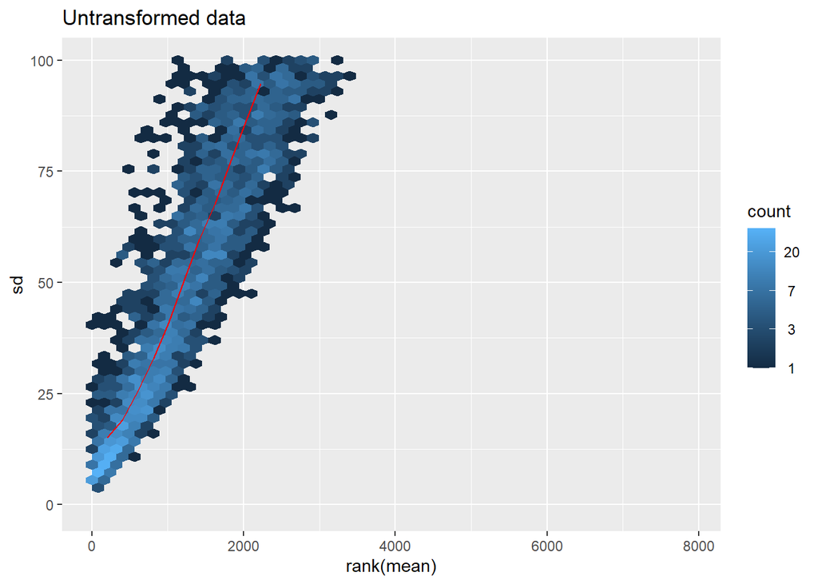

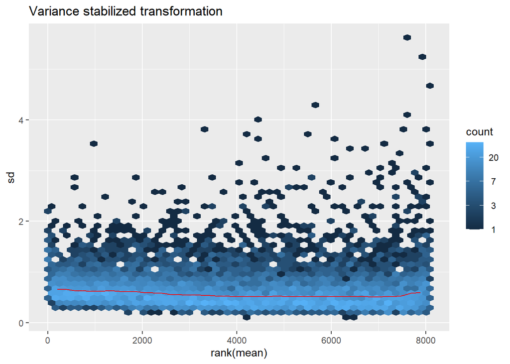

```r
msd_dds$gg + ggtitle("Untransformed data") + ylim(-1,100)
msd_vsd$gg + ggtitle("Variance stabilized transformation")
```

#### Supervised clustering

```r
# find 15 genes with highest expression levels from dds
select <- order(rowMeans(counts(dds,normalized=TRUE)),
                decreasing=TRUE)[1:15]

# make new data frame with only Population stage info
df <- as.data.frame(colData(dds)[,c("Population")])
colnames(df) <- c("Population")
#samples <- colnames(assay(ntd))
samples <- metadata$Sample_ID
rownames(df) <- samples

# heatmap of variance stabilized data
library(pheatmap)
# extract data
mat <- assay(vsd)[select,]
top20 <- row.names(mat)
colnames(mat) <- metadata$Sample_ID

# remove the random prefix and suffixes
row.names(mat) <- gsub("^[^-]+-|\\.m01$", "", row.names(mat))
row.names(mat)
```

```
##  [1] "Ap.00g078360" "Ap.00g054880" "Ap.00g019870" "Ap.00g054640" "Ap.00g057760"
##  [6] "MLGFLVLP"     "Ap.00g068810" "Ap.00g039900" "SFFFPIP"      "Ap.00g008070"
## [11] "GPVFFAY"      "Ap.00g078370" "Ap.00g011790" "Ap.00g001030" "Ap.00g063180"
```

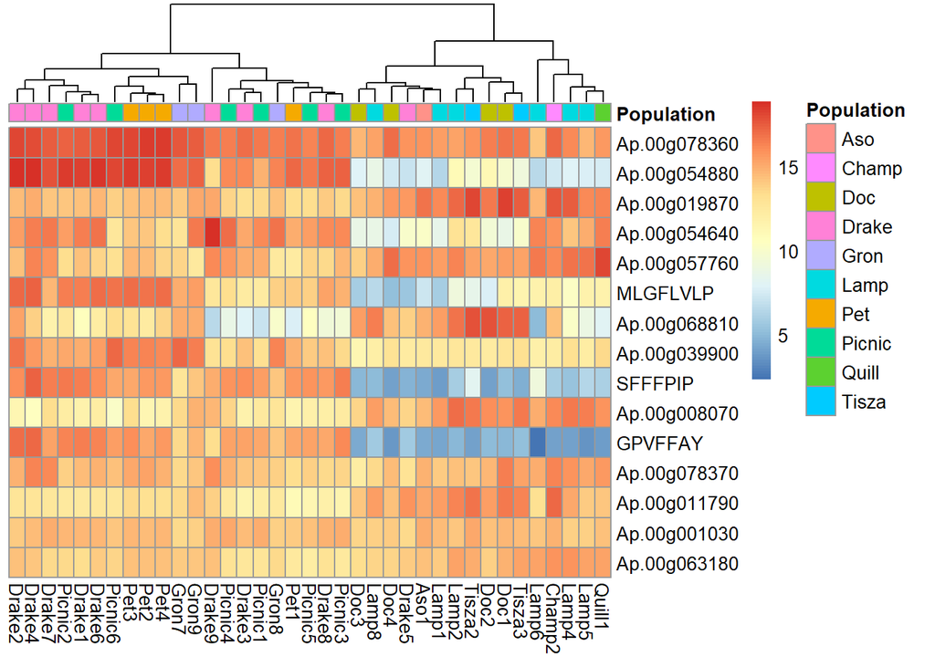

```r
pheatmap(mat, cluster_rows=FALSE,
         show_rownames=TRUE,
         cluster_cols=TRUE, annotation_col=df)
```

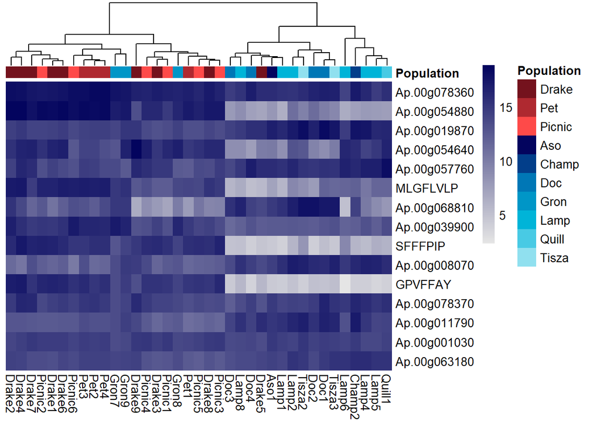

```r
# also make heatmap of genes with custom colors
genotype_colors <- c("#74121D","#af2930","#FE4A49",
                     "#03045e","#023e8a","#0077b6","#0096c7","#00b4d8","#48cae4","#90e0ef")

annotation_colors <- list(Population = setNames(genotype_colors, unique(df$Population)))

# Define your custom color scale (from dark blue to aqua)
my_colors <- colorRampPalette(c("grey90","#03045e"))(100)


pheatmap(mat, cluster_rows=FALSE,
         show_rownames=TRUE,
         cluster_cols=TRUE,
         annotation_col=df,
         annotation_colors = annotation_colors,
         legend=TRUE,
         color=my_colors,
         border_color = "transparent",
         fontsize_row = 10,  # Row label font size
         fontsize_col = 10)
```

#### PCA / unsupervised clustering

A great interactive explanation of PCA plots is [here](https://bioboot.github.io/bggn213_F20/class-material/pca/)

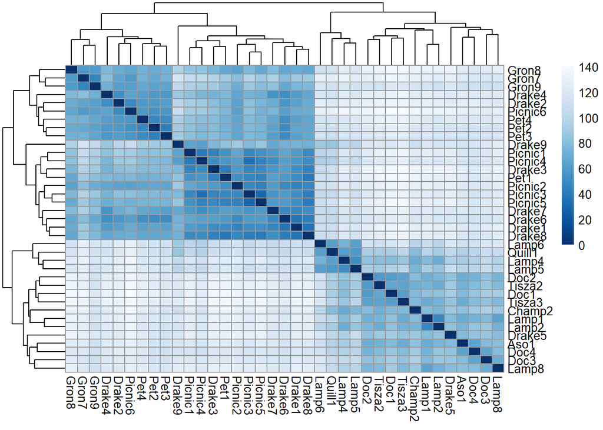

```r
# find distances between samples
sampleDists <- dist(t(assay(vsd)))

# reformat distances
sampleDistMatrix <- as.matrix(sampleDists)

# make row and column names the same as sample IDs
rownames(sampleDistMatrix) <- rownames(df)
colnames(sampleDistMatrix) <- rownames(df)

# generate some nice colors
library(RColorBrewer)
colors <- colorRampPalette( rev(brewer.pal(9, "Blues")) )(255)

# plot it
pheatmap(sampleDistMatrix,
         clustering_distance_rows=sampleDists,
         clustering_distance_cols=sampleDists,
         col=colors)
```

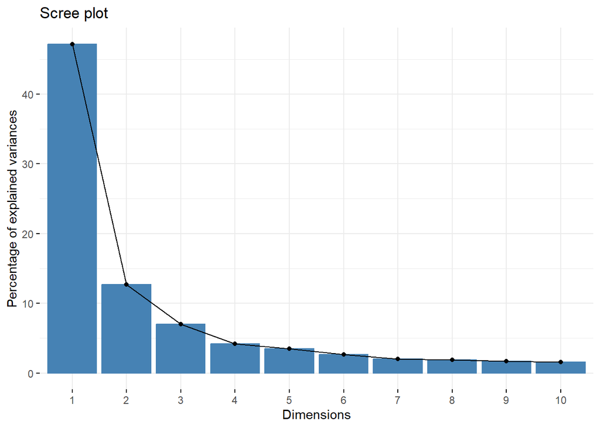

```r
# next lets generate a PCA plot on variance stabilized data
vsd_out <- assay(vsd)

# run PCA analysis
pca <- prcomp(t(vsd_out))

# plot scree
library(factoextra)
fviz_eig(pca)
```

```r
# Create data frame with metadata and PC3 and PC4 values for input to ggplot
pcaData <- cbind(metadata[,c(2:5,8,13)], pca$x)

# Define color palette for genotypes
pcaData$Origin <- factor(pcaData$Origin, levels = c("CA",
                                                    "EU"))

genotype_colors <- c("#FE4A49", "#2292A4")

# find percent variance for PC1 and PC2
# summary of variance
pcasummary <- summary(pca)
pcasummary
```

```
## Importance of components:
##                            PC1     PC2      PC3      PC4      PC5      PC6
## Standard deviation     49.7044 25.8066 19.13221 14.78744 13.52954 11.80978
## Proportion of Variance  0.4717  0.1272  0.06989  0.04175  0.03495  0.02663
## Cumulative Proportion   0.4717  0.5989  0.66875  0.71051  0.74546  0.77209
##                             PC7     PC8     PC9    PC10    PC11   PC12    PC13
## Standard deviation     10.29650 9.94409 9.35800 9.14385 8.16263 8.0259 7.62119
## Proportion of Variance  0.02024 0.01888 0.01672 0.01596 0.01272 0.0123 0.01109
## Cumulative Proportion   0.79233 0.81121 0.82793 0.84389 0.85661 0.8689 0.88000
##                           PC14    PC15    PC16    PC17    PC18    PC19   PC20
## Standard deviation     7.31282 7.06540 6.88098 6.48477 6.33989 6.11415 5.9695
## Proportion of Variance 0.01021 0.00953 0.00904 0.00803 0.00767 0.00714 0.0068
## Cumulative Proportion  0.89021 0.89975 0.90879 0.91681 0.92449 0.93163 0.9384
##                           PC21    PC22    PC23    PC24    PC25    PC26    PC27
## Standard deviation     5.92059 5.63675 5.56342 5.07650 4.98911 4.78476 4.60256
## Proportion of Variance 0.00669 0.00607 0.00591 0.00492 0.00475 0.00437 0.00404
## Cumulative Proportion  0.94512 0.95119 0.95710 0.96202 0.96677 0.97114 0.97519
##                           PC28   PC29    PC30    PC31    PC32    PC33    PC34
## Standard deviation     4.53083 4.4004 4.21240 4.02068 3.99395 3.62851 3.34748
## Proportion of Variance 0.00392 0.0037 0.00339 0.00309 0.00305 0.00251 0.00214
## Cumulative Proportion  0.97911 0.9828 0.98619 0.98928 0.99233 0.99484 0.99698
##                           PC35   PC36                PC37
## Standard deviation     2.91502 2.7063 0.00000000000004468
## Proportion of Variance 0.00162 0.0014 0.00000000000000000
## Cumulative Proportion  0.99860 1.0000 1.00000000000000000
```

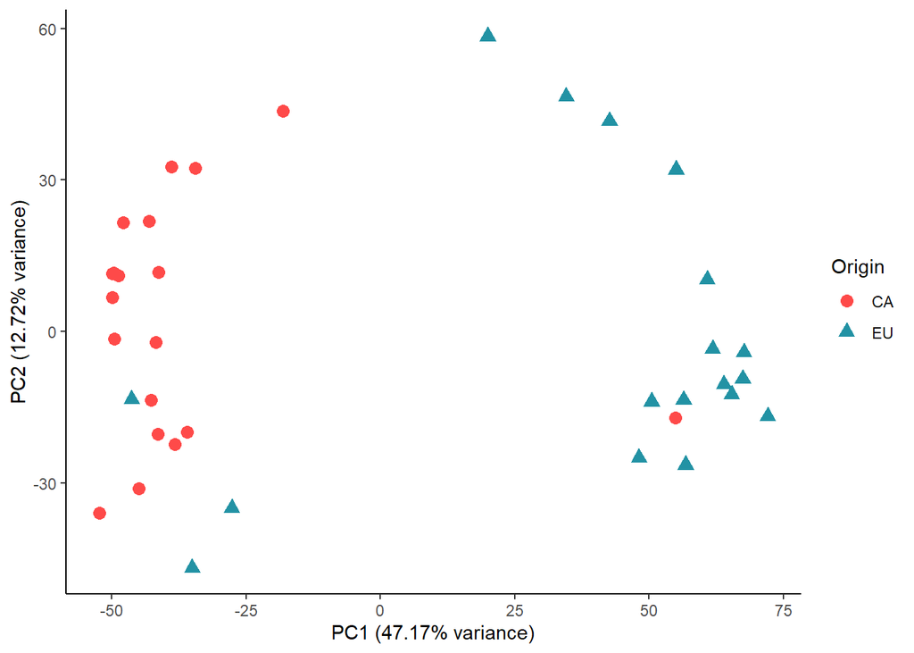

```r
pc1var <- round(pcasummary$importance[2],digits = 4) * 100
pc2var <- round(pcasummary$importance[5],digits = 4) * 100
pc3var <- round(pcasummary$importance[8],digits = 4) * 100
pc4var <- round(pcasummary$importance[11],digits = 4) * 100


# plot PC1 and 2
ggplot(pcaData,aes(x=PC1, y=PC2, color = Origin, shape = Origin)) +
  geom_point(size=3) +
  theme_classic() +
  scale_color_manual(values = genotype_colors) +
  xlab(paste0("PC1 (",pc1var,"% variance)")) +
  ylab(paste0("PC2 (",pc2var,"% variance)"))
```

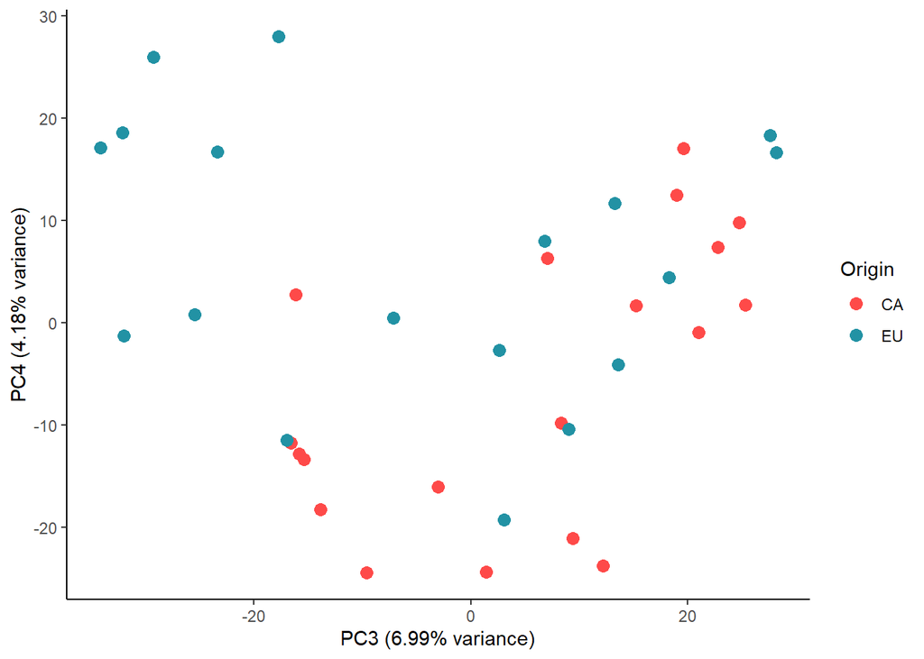

```r
ggsave("PCA_plot_pc12_origin.png",
       path = subDir,
       units="in",
       width = 6, height = 5)

# plot PC3 and 4
ggplot(pcaData,aes(x=PC3, y=PC4, color = Origin, size = Origin)) +
  geom_point(size=3) +
  theme_classic() +
  scale_color_manual(values = genotype_colors) +
  xlab(paste0("PC3 (",pc3var,"% variance)")) +
  ylab(paste0("PC4 (",pc4var,"% variance)"))
```

```r
ggsave("PCA_plot_pc34_origin.png",
       path = subDir,
       units="in",
       width = 6, height = 5)

# also plot where colors indicate population & shape indicates Origin

# deduplicate
t <- unique(metadata[,c(4,8)])
t
```

```
## # A tibble: 10 × 2
##    Population Origin
##    <chr>      <fct>
##  1 Drake      CA
##  2 Pet        CA
##  3 Picnic     CA
##  4 Aso        EU
##  5 Champ      EU
##  6 Doc        EU
##  7 Gron       EU
##  8 Lamp       EU
##  9 Quill      EU
## 10 Tisza      EU
```

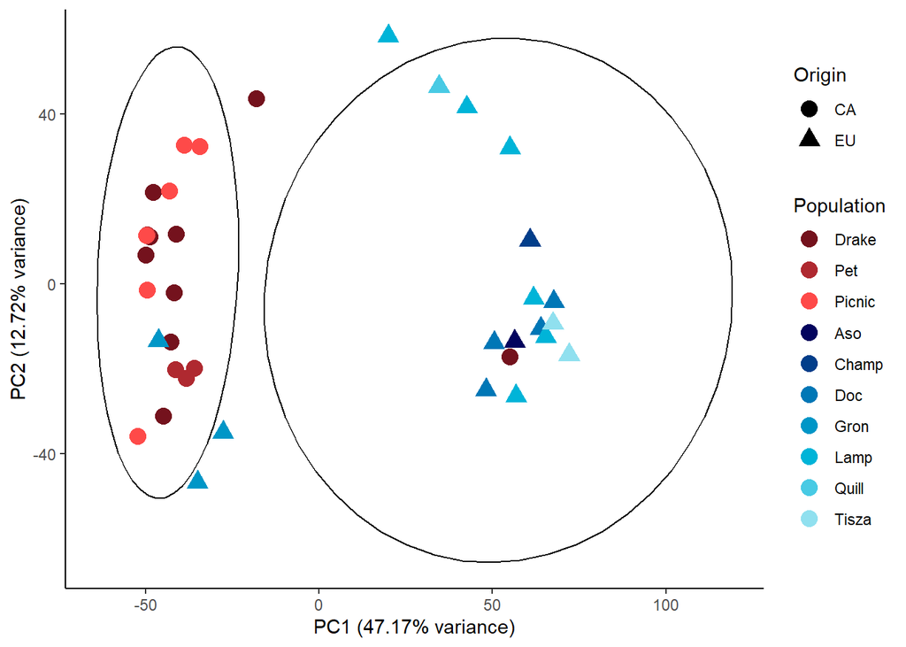

```r
pcaData$Population <- factor(pcaData$Population, levels = c("Drake",
                                                            "Pet",
                                                            "Picnic",
                                                            "Aso",
                                                            "Champ",
                                                            "Doc",
                                                            "Gron",
                                                            "Lamp",
                                                            "Quill",
                                                            "Tisza"))
# first 3 are CA, last 7 are EU
genotype_colors <- c("#74121D","#af2930","#FE4A49",
                     "#03045e","#023e8a","#0077b6","#0096c7","#00b4d8","#48cae4","#90e0ef")


ggplot(pcaData,aes(x=PC1, y=PC2, color = Population, shape = Origin)) +
  geom_point(size=4) +
  theme_classic() +
  scale_color_manual(values = genotype_colors) +
stat_ellipse(aes(group = Origin), colour = "black")+
  xlab(paste0("PC1 (",pc1var,"% variance)")) +
  ylab(paste0("PC2 (",pc2var,"% variance)"))
```

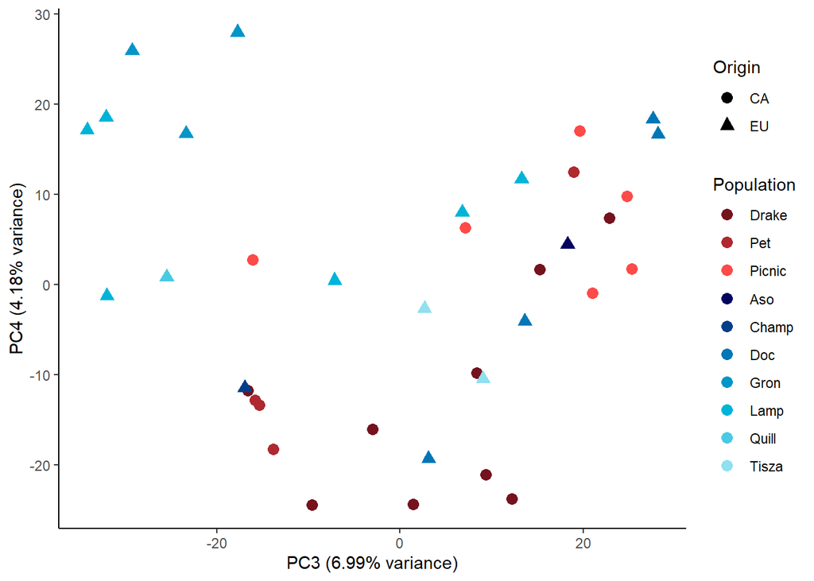

```r
ggsave("PCA_plot_pc12_population_origin.png",
       path = subDir,
       units="in",
       width = 6, height = 5)

ggplot(pcaData,aes(x=PC3, y=PC4, color = Population, shape = Origin)) +
  geom_point(size=3) +
  theme_classic() +
  scale_color_manual(values = genotype_colors) +
  xlab(paste0("PC3 (",pc3var,"% variance)")) +
  ylab(paste0("PC4 (",pc4var,"% variance)"))
```

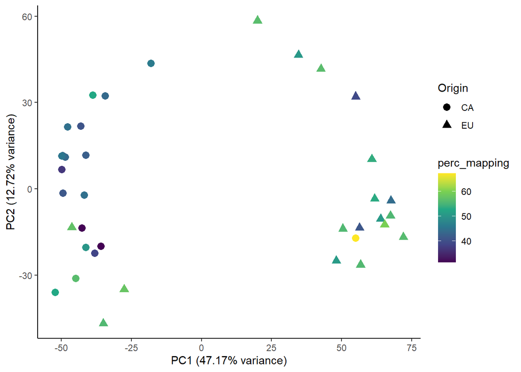

```r
ggsave("PCA_plot_pc34_population_origin.png",
       path = subDir,
       units="in",
       width = 6, height = 5)

## now plot PCA where color indicates mapping rate
ggplot(pcaData,aes(x=PC1, y=PC2, color = perc_mapping, shape = Origin)) +
  geom_point(size=3) +
  theme_classic() +
  scale_color_viridis_c() +
  #paletteer::scale_color_paletteer_c("viridis::plasma") +
  #scale_color_manual(values = genotype_colors) +
  xlab(paste0("PC1 (",pc1var,"% variance)")) +
  ylab(paste0("PC2 (",pc2var,"% variance)"))
```

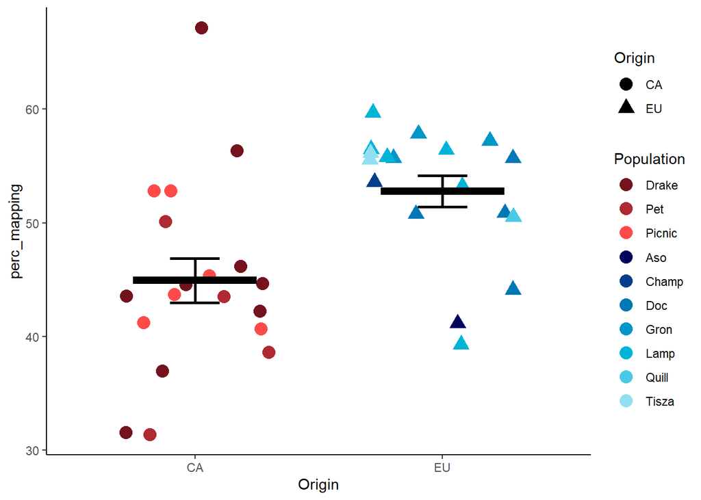

```r
ggsave("PCA_plot_pc12_percmapping_origin.png",
       path = subDir,
       units="in",
       width = 6, height = 5)

# plot mapping rates for both pops
ggplot(pcaData, aes(x=Origin,y=perc_mapping, color=Population,shape=Origin)) +
  geom_point(size = 4, position = position_jitter(w = 0.3, h = 0)) +
  # add mean line
  stat_summary(fun= mean, fun.min=mean, fun.max=mean, geom="crossbar", width=0.5, linewidth=1,color="black") +
  # add error bars
  stat_summary(fun.data=mean_se, fun.args = list(mult=1), geom="errorbar", width=0.2, linewidth=1,color="black") +
  scale_color_manual(values = genotype_colors) +
  theme_classic()
```

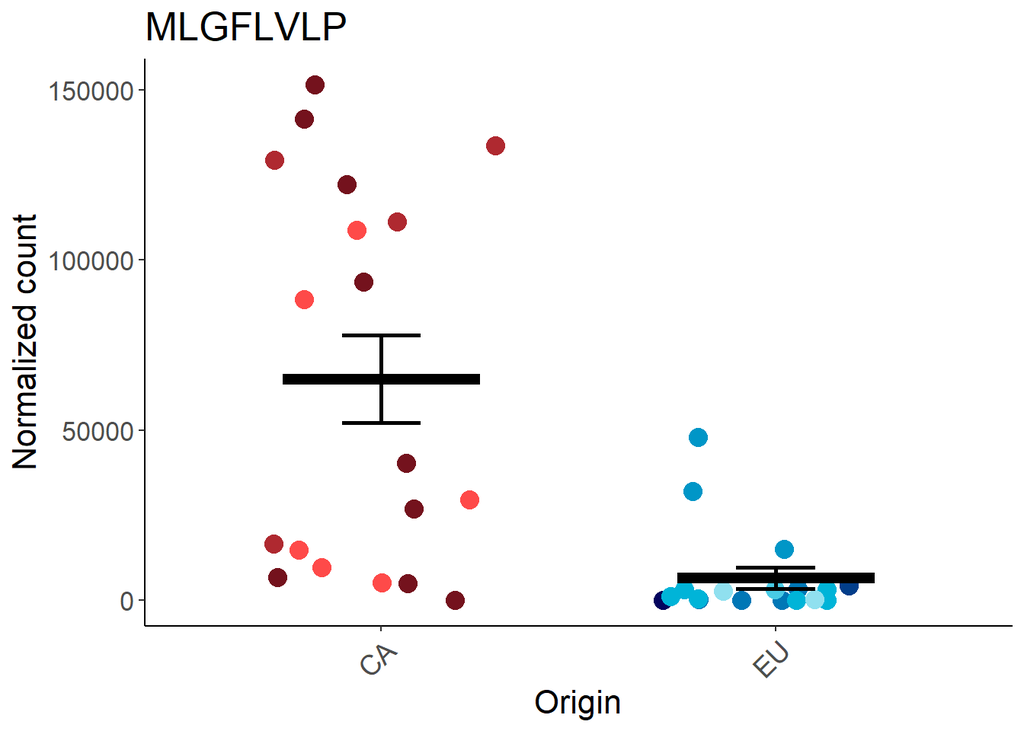

```r
ggsave("percmapping_origin_population.png",
       path = subDir,
       units="in",
       width = 4, height = 5)

# export pca data for separate graphing
write.csv(pcaData[,1:10],paste0(subDir,"/pca_data.csv"),row.names=FALSE)


# also plot norm counts for leaderless with population colored...
gene <- plotCounts(dds, gene = "MLGFLVLP", intgroup = "Origin", returnData = TRUE)

  # Define color palette for Origin
  gene$Origin <- factor(gene$Origin, levels = c("CA",
                                                    "EU"))
  gene$Population <- metadata$Population

  gene$Population <- factor(gene$Population, levels = c("Drake",
                                                            "Pet",
                                                            "Picnic",
                                                            "Aso",
                                                            "Champ",
                                                            "Doc",
                                                            "Gron",
                                                            "Lamp",
                                                            "Quill",
                                                            "Tisza"))
ggplot(data=gene,aes(x=Origin,y=count)) +
  geom_point(aes(colour = Population), size = 4, position = position_jitter(w = 0.3, h = 0)) +
  # add mean line
  stat_summary(fun= mean, fun.min=mean, fun.max=mean, geom="crossbar", width=0.5, linewidth=1,color="black") +
  # add error bars
  stat_summary(fun.data=mean_se, fun.args = list(mult=1), geom="errorbar", width=0.2, linewidth=1,color="black") +
  theme_classic()  +
  scale_color_manual(values = genotype_colors) +
  theme(legend.position = "none",
        text = element_text(size = 16),
        axis.text.x = element_text(angle = 45, hjust = 1, size = 14)) +
  ylab("Normalized count") +
  ggtitle("MLGFLVLP")
```

```r
  # save graph
  ggsave(paste0("MLGFLVLP","_pop_normalized_counts.png"),
         device="png",dpi="print",
         units = "in", width = 5, height = 3,
         path=paste0(subDir,"/NormCount-Graphs"))
```

### pretty plots

make a new table keeping only log2FC and padj for each genotyp

write a function to mini-fy each table

group1 or group2 = comparison from deseq you want to make mini

```r
make_mini <- function(group1,group2,prefix="",keepmean=TRUE) {
  # group1 = "veA_wildtype_ctrl"
  # group2 = "veA_wildtype_TSA"
  # prefix = "veA_wildtype"
  temp <- as.data.frame(results(dds,
                                contrast=c("Origin", group1, group2),
                                alpha=0.05,
                                , independentFiltering=FALSE, cooksCutoff=TRUE))
  temp$ID <- row.names(temp)

  output <- temp[,c("ID","baseMean","log2FoldChange","padj")]
  colnames(output) <- c("ID","baseMean",
                        paste0(prefix,"_L2FC"),
                        paste0(prefix,"_padj"))

  # if specified above, do not keep the baseMean column
  if(keepmean==FALSE) {
    output <- output[,c("ID",
                        paste0(prefix,"_L2FC"),
                        paste0(prefix,"_padj"))]
  }

  return(output)
}

deseq_results <- make_mini("EU","CA","EU_vs_CA")
deseq_results$ID <- gsub("^[^-]+-|\\.m01$", "", deseq_results$ID )

# subset to include only msdins
```

heatmap, Violin plot, pca plot, and facet_wrap for all msdins

```r
# also make heatmap of genes with custom colors
genotype_colors <- c("#74121D","#af2930","#FE4A49",
                     "#03045e","#023e8a","#0077b6","#0096c7","#00b4d8","#48cae4","#90e0ef")

annotation_colors <- list(Population = setNames(genotype_colors, unique(df$Population)))

# Define your custom color scale (from dark blue to aqua)
my_colors <- colorRampPalette(c("grey90","#03045e"))(100)

# log transform count data
mat_log <- counts(dds, normalized=TRUE)[select,]
mat_log <- log10(mat_log)

top20 <- row.names(mat_log)
colnames(mat_log) <- metadata$Sample_ID

# remove the random prefix and suffixes
row.names(mat_log) <- gsub("^[^-]+-|\\.m01$", "", row.names(mat_log))
row.names(mat_log)
```

```
##  [1] "Ap.00g078360" "Ap.00g054880" "Ap.00g019870" "Ap.00g054640" "Ap.00g057760"
##  [6] "MLGFLVLP"     "Ap.00g068810" "Ap.00g039900" "SFFFPIP"      "Ap.00g008070"
## [11] "GPVFFAY"      "Ap.00g078370" "Ap.00g011790" "Ap.00g001030" "Ap.00g063180"
```

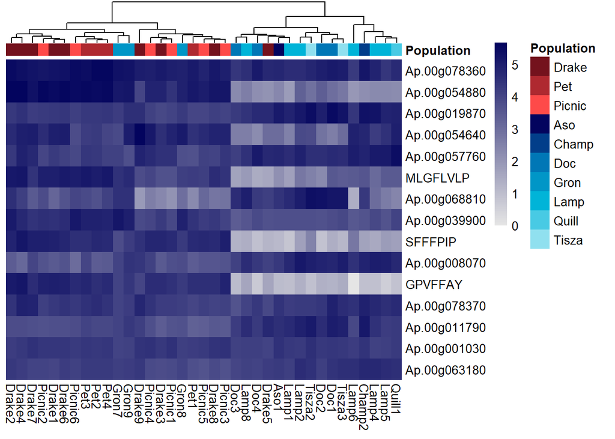

```r
# remove log10(0) values that are -Inf
mat_log[mat_log == -Inf] <- 0

library(grid)


heatmap_plot <- pheatmap(mat_log, cluster_rows=FALSE,
         show_rownames=TRUE,
         cluster_cols=TRUE,
         treeheight_col = 30,
         annotation_col=df,
         annotation_colors = annotation_colors,
         legend=TRUE,
         color=my_colors,
         legend_width = unit(0.2, "in"),
         legend_position = "right",
         border_color = "transparent")
```

```r
gtable_obj <- heatmap_plot$gtable

# Modify the legend's vertical position
# Find the legend in the gtable and move it up
gtable_obj$grobs[[which(gtable_obj$layout$name == "legend")]]$grobs[[1]]$gp <- gpar(fontsize = 20)  # Set the font size to 10


# Modify the y position of the annotation_colors legend
# Adjust the y-coordinate to move the legend up
annotation_legend_index <- which(gtable_obj$layout$name == "annotation_legend")
gtable_obj$grobs[[annotation_legend_index]]$grobs[[1]]$gp <- gpar(fontsize = 20)  # Set the font size to 10



# Draw the modified heatmap with legend moved up
pdf(paste0(subDir,"/heatmap.pdf"), width = 8, height = 5, family="ArialMT")  # Specify desired width and height

grid.draw(gtable_obj)
dev.off()
```

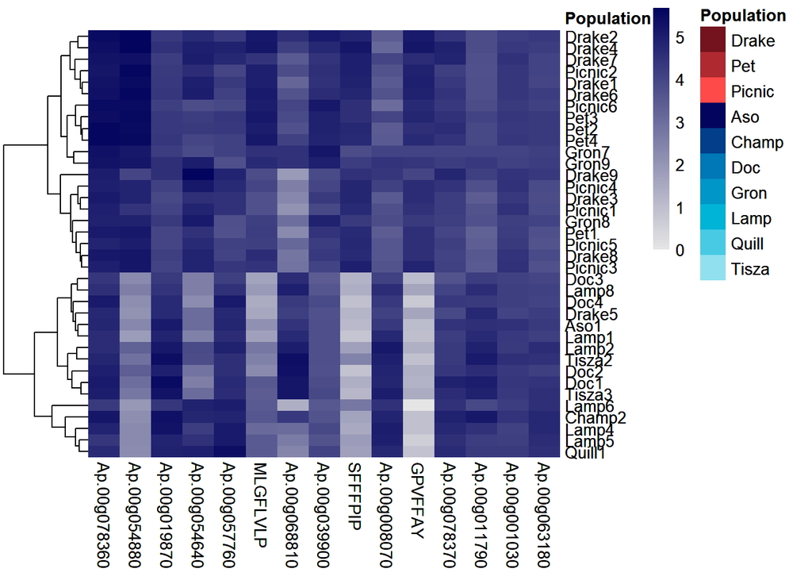

```r
# Transpose the matrix
mat_rotated <- t(mat_log)

pdf(paste0(subDir,"/heatmap_transposed.pdf"), width = 5, height = 8, family="ArialMT")  # Specify desired width and height

heatmap_plot<-pheatmap(mat_rotated, cluster_rows=TRUE,
         show_rownames=TRUE,
         cluster_cols=FALSE,
         treeheight_col = 30,
         annotation_col=df,
         annotation_colors = annotation_colors,
         legend=TRUE,
         color=my_colors,
         legend_width = unit(0.2, "in"),
         legend_position = "right",
         border_color = "transparent")
gtable_obj <- heatmap_plot$gtable
grid.draw(gtable_obj)
```

```r
dev.off()
```

```r
######### FACET_WRAP VSD COUNTS
# extract variance stabilized gene count data for all msdin genes

# list of all msdins
list
```

```
##  [1] "AWLATCP"    "AWLVDCP"    "FFFPPFFIPP" "FFPIVFSPP"  "FMPLAP"
##  [6] "FNILPFMLPP" "FNLFRFPYP"  "GPVFFAY"    "HFASFIPP"   "IFLAFPIPP"
## [11] "IFWFIYFP"   "IIGILLPP"   "IRLPPLFLPP" "ISDPTAYP"   "IWGIGCDP"
## [16] "IWGIGCDP_1" "IWGIGCNP"   "LFFWFWFLWP" "LGRPESLP"   "LILLAALGIP"
## [21] "LIQRPFAP"   "LIQRPFAP_1" "LRLPPFMIPP" "MLGFLVLP"   "SFFFPIP"
## [26] "VQKPWSRP"
```

```r
# generate facet_wrap for these samples

# extract data
mat2 <- as.data.frame(counts(dds,normalized=TRUE)[list,])
# log transform
mat2 <- log10(mat2)
# remove log10(0) values that are -Inf
mat2[mat2 == -Inf] <- 0
colnames(mat2) <- metadata$Sample_ID

# Reshape the data from wide to long format
library(tidyverse)
```

```r
mat2_long <- mat2 %>%
  rownames_to_column("MSDIN") %>%        # Convert row names into a column
  pivot_longer(cols = -MSDIN,            # Pivot columns except for "Row"
               names_to = "Sample_ID",    # New column for column names
               values_to = "Value")    # New column for values

# add a new column to facet over:
# msdin type
msdin_type <- c("Canonical","Leaderless","Prolineless")
noncanonical <- c("MLGFLVLP","GPVFFAY")

# Add the "Type" column
mat2_long$Type <- ifelse(mat2_long$MSDIN %in% noncanonical, "Noncanonical", "Canonical")
mat2_long$Type <- ifelse(mat2_long$MSDIN %in% "MLGFLVLP", "Leaderless",mat2_long$Type)
mat2_long$Type <- ifelse(mat2_long$MSDIN %in% "GPVFFAY", "Prolineless",mat2_long$Type)

# add additional metadata:
# Population
metadata2 <- metadata[,c("Sample_ID","Population","Origin")]
mat2_long <- mat2_long %>%
  left_join(metadata2, by = "Sample_ID")

# set order
mat2_long$Origin <- factor(mat2_long$Origin, levels = c("CA",
                                                    "EU"))

mat2_long$Population <- factor(mat2_long$Population, levels = c("Drake",
                                                            "Pet",
                                                            "Picnic",
                                                            "Aso",
                                                            "Champ",
                                                            "Doc",
                                                            "Gron",
                                                            "Lamp",
                                                            "Quill",
                                                            "Tisza"))

# extract p values for each MSDIN
deseq_msdin <- deseq_results[list,]

# round p values
options(scipen = 999)

deseq_msdin$EU_vs_CA_padj <- signif(deseq_msdin$EU_vs_CA_padj, 3)
deseq_msdin$EU_vs_CA_padj <- formatC(deseq_msdin$EU_vs_CA_padj, format = "g", digits = 3)

colnames(deseq_msdin)[1] <-"MSDIN"
# merge this onto mat2_long
mat2_long <- merge(mat2_long,deseq_msdin,by="MSDIN",all.x=TRUE)
mat2_long$EU_vs_CA_padj <- as.numeric(mat2_long$EU_vs_CA_padj)

# now plot it and facet by MSDIN
pdf(paste0(subDir,"/log10_msdin.pdf"), width = 12, height = 12, family="ArialMT")  # Specify desired width and height

ggplot(data=mat2_long,aes(x=Origin,y=Value)) +
  geom_point(aes(colour = Population), size = 4, position = position_jitter(w = 0.3, h = 0)) +
  # add mean line
  stat_summary(fun= mean, fun.min=mean, fun.max=mean, geom="crossbar", width=0.5, linewidth=1,color="black") +
  # add error bars
  stat_summary(fun.data=mean_se, fun.args = list(mult=1), geom="errorbar", width=0.2, linewidth=1,color="black") +
  theme_classic()  +
  scale_color_manual(values = genotype_colors) +
  theme(legend.position = "none",
        text = element_text(size = 16),
        axis.text.x = element_text(angle = 45, hjust = 1, size = 10)) +
  ylab("Log10(normalized count)") +
  facet_wrap(Type~MSDIN)+
  # Add p-value labels on each facet
  geom_text(aes(x = 1.5, y = max(Value) * 0.9, label = sprintf("p = %.3f", EU_vs_CA_padj)), size = 5, color = "black", inherit.aes = FALSE)

dev.off()
```

```r
# also do this with normalized counts
# extract data
mat3 <- as.data.frame(counts[list,])
colnames(mat3) <- metadata$Sample_ID

# Reshape the data from wide to long format
mat3_long <- mat3 %>%
  rownames_to_column("MSDIN") %>%        # Convert row names into a column
  pivot_longer(cols = -MSDIN,            # Pivot columns except for "Row"
               names_to = "Sample_ID",    # New column for column names
               values_to = "Value")    # New column for values

# add a new column to facet over:
# msdin type
msdin_type <- c("canonical","leaderless","prolineless")
noncanonical <- c("MLGFLVLP","GPVFFAY")

# Add the "Type" column
mat3_long$Type <- ifelse(mat3_long$MSDIN %in% noncanonical, "noncanonical", "canonical")
mat3_long$Type <- ifelse(mat3_long$MSDIN %in% "MLGFLVLP", "leaderless",mat3_long$Type)
mat3_long$Type <- ifelse(mat3_long$MSDIN %in% "GPVFFAY", "prolineless",mat3_long$Type)

# add additional metadata:
# Population
metadata2 <- metadata[,c("Sample_ID","Population","Origin")]
mat3_long <- mat3_long %>%
  left_join(metadata2, by = "Sample_ID")

# set order
mat3_long$Origin <- factor(mat3_long$Origin, levels = c("CA",
                                                    "EU"))

mat3_long$Population <- factor(mat3_long$Population, levels = c("Drake",
                                                            "Pet",
                                                            "Picnic",
                                                            "Aso",
                                                            "Champ",
                                                            "Doc",
                                                            "Gron",
                                                            "Lamp",
                                                            "Quill",
                                                            "Tisza"))



# now plot it and facet by MSDIN
pdf(paste0(subDir,"/normcount_msdin.pdf"), width = 12, height = 12, family="ArialMT")  # Specify desired width and height

ggplot(data=mat3_long,aes(x=Origin,y=Value)) +
  geom_point(aes(colour = Population), size = 4, position = position_jitter(w = 0.3, h = 0)) +
  # add mean line
  stat_summary(fun= mean, fun.min=mean, fun.max=mean, geom="crossbar", width=0.5, linewidth=1,color="black") +
  # add error bars
  stat_summary(fun.data=mean_se, fun.args = list(mult=1), geom="errorbar", width=0.2, linewidth=1,color="black") +
  theme_classic()  +
  scale_color_manual(values = genotype_colors) +
  theme(legend.position = "none",
        text = element_text(size = 16),
        strip.background = element_blank(),
        strip.text = element_text(face = "bold"),
        axis.text.x = element_text(angle = 45, hjust = 1, size = 10)) +
  ylab("Normalized count") +
  facet_wrap(~MSDIN, scales = "free_y")

dev.off()
```

```r
# adjust type names for the graph
mat2_long <- mat2_long %>%
  mutate(Type = recode(Type,
                       "canonical" = "Canonical MSDINs",
                       "prolineless" = "Prolineless GPVFFAY",
                       "leaderless" = "Leaderless MLGFLVLP"))

genotype_colors <- c("#74121D","#af2930","#FE4A49",
                     "#03045e","#023e8a","#0077b6","#0096c7","#00b4d8","#48cae4","#90e0ef")


pdf(paste0(subDir,"/violin.pdf"), width = 4.5, height = 2.5, family="ArialMT")

ggplot(data=mat2_long,aes(x=Origin,y=Value,fill=Origin)) +
geom_violin(trim = FALSE, adjust = 0.6, draw_quantiles = c(0.25, 0.75), linetype = "dashed") +
  geom_violin(trim = FALSE, adjust = 0.6, draw_quantiles = 0.5, fill="transparent") +
  theme_classic()  +
  scale_fill_manual(values = c("#FE4A49", "#00b4d8")) +
  ylab("Log10(normalized count)") +
  #geom_hline(yintercept = 0, color = "black", linetype = "solid", size = 1) +  # Black line at y=0
  facet_wrap(~Type) +
  theme(panel.spacing = unit(0, "lines"),
        strip.background = element_blank(),
        strip.text = element_text(face = "bold"),
        legend.position = "none",
        text = element_text(color = "black",size = 10))

dev.off()
```

```r
##### PCA PLOT

pdf(paste0(subDir,"/pca.pdf"), width = 4.5, height = 2.5, family="ArialMT")  # Specify desired width and height

ggplot(pcaData,aes(x=PC1, y=PC2, color = Population, shape=Origin)) +
  geom_point(size=3) +
  theme_classic() +
  scale_color_manual(values = genotype_colors) +
stat_ellipse(aes(group = Origin), colour = "black")+
  xlab(paste0("PC1 (",pc1var,"% variance)")) +
  ylab(paste0("PC2 (",pc2var,"% variance)")) +
  theme(panel.spacing = unit(0, "lines"),
        strip.background = element_blank(),
        text = element_text(color = "black",size = 10),
        legend.key.height = unit(0.15, 'in'))+
  guides(color = guide_legend(override.aes=list(shape = c(rep(16,3),rep(17,7)))))  # Customize shape of color legend


dev.off()
```

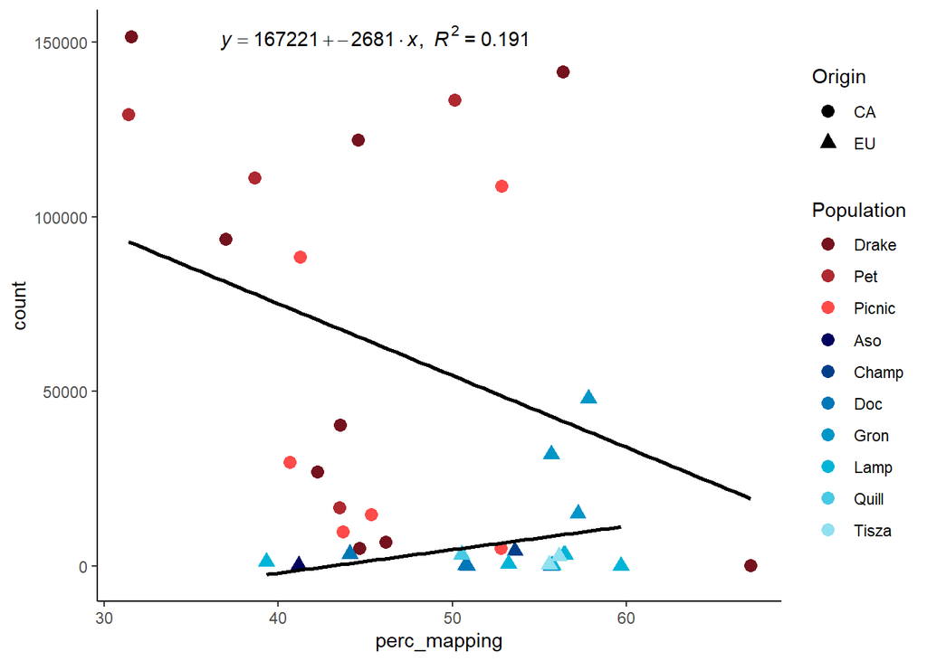

```r
# finally: also plot mapping rate for samples vs. counts for leaderless
dat <- read.csv("C:/Users/livia/Documents/02-drott-lab-files/leaderless_Aphalloides/Output_2025-02-20/NormCount-Graphs/Data/MLGFLVLP.csv")
colnames(dat)[1] <- "File_prefix"
mini_meta <- metadata[,c("File_prefix","perc_mapping")]

# merge
dat2 <- merge(dat,mini_meta,by="File_prefix",all.x=TRUE)

dat2$Origin <- factor(dat2$Origin, levels = c("CA",
                                                    "EU"))

dat2$Population <- factor(dat2$Population, levels = c("Drake",
                                                            "Pet",
                                                            "Picnic",
                                                            "Aso",
                                                            "Champ",
                                                            "Doc",
                                                            "Gron",
                                                            "Lamp",
                                                            "Quill",
                                                            "Tisza"))


library(ggplot2)

# Fit the linear model
# for all points:
lm_model <- lm(count ~ perc_mapping, data = dat2)

# based on origin:
ca <- subset(dat2,Origin == "CA")
eu <- subset(dat2,Origin == "EU")

lm_model_ca <- lm(count ~ perc_mapping, data = ca)
lm_model_eu <- lm(count ~ perc_mapping, data = eu)

eqn_ca <- substitute(italic(y) == a + b %.% italic(x) * "," ~~ italic(R)^2 ~ "=" ~ r2,
                  list(a = as.numeric(format(coef(lm_model_ca)[1], digits = 3)),
                       b = as.numeric(format(coef(lm_model_ca)[2], digits = 3)),
                       r2 = format(summary(lm_model_ca)$r.squared, digits = 3)))

eqn_eu <- substitute(italic(y) == a + b %.% italic(x) * "," ~~ italic(R)^2 ~ "=" ~ r2,
                  list(a = as.numeric(format(coef(lm_model_eu)[1], digits = 3)),
                       b = as.numeric(format(coef(lm_model_eu)[2], digits = 3)),
                       r2 = format(summary(lm_model_eu)$r.squared, digits = 3)))

# Extract coefficients and R-squared
eqn <- substitute(italic(y) == a + b %.% italic(x) * "," ~~ italic(R)^2 ~ "=" ~ r2,
                  list(a = as.numeric(format(coef(lm_model)[1], digits = 3)),
                       b = as.numeric(format(coef(lm_model)[2], digits = 3)),
                       r2 = format(summary(lm_model)$r.squared, digits = 3)))

genotype_colors <- c("#74121D","#af2930","#FE4A49",
                     "#03045e","#023e8a","#0077b6","#0096c7","#00b4d8","#48cae4","#90e0ef")

ggplot(dat2, aes(x=perc_mapping,y=count,color=Population, shape=Origin)) +
  geom_point(size=3) +
  scale_color_manual(values = genotype_colors) +
  geom_smooth(method = "lm", se = FALSE, color = "black") +  # Add linear regression line
  annotate("text", x = min(dat2$perc_mapping), y = max(dat2$count),
           label = as.character(as.expression(eqn)), parse = TRUE, hjust = -0.3) +  # Add equation
  theme_classic()
```

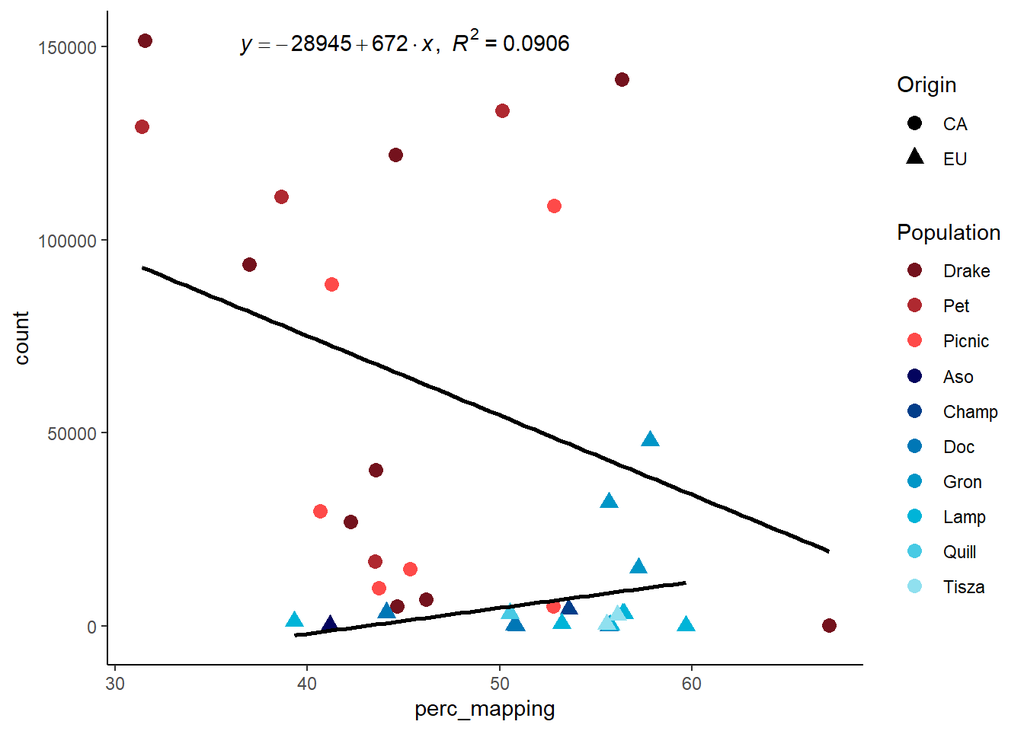

```r
ggsave("mapping_vs_leaderless_counts.png",
       path = subDir,
       units="in",
       width = 6, height = 5)
ggplot(dat2, aes(x=perc_mapping,y=count,color=Population, shape=Origin)) +
  geom_point(size=3) +
  scale_color_manual(values = genotype_colors) +
  geom_smooth(method = "lm", se = FALSE, color = "black") +  # Add linear regression line
  annotate("text", x = min(dat2$perc_mapping), y = max(dat2$count),
           label = as.character(as.expression(eqn_eu)), parse = TRUE, hjust = -0.3) +  # Add equation
  theme_classic()
```

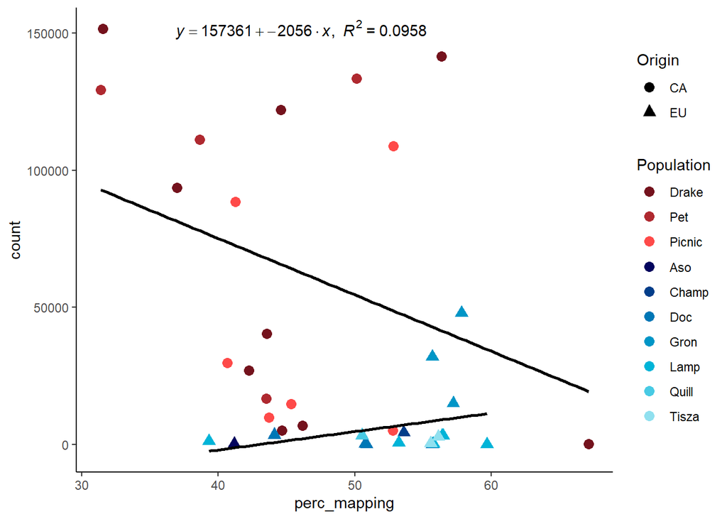

```r
ggsave("mapping_vs_leaderless_counts_EUlm.png",
       path = subDir,
       units="in",
       width = 6, height = 5)
ggplot(dat2, aes(x=perc_mapping,y=count,color=Population, shape=Origin)) +
  geom_point(size=3) +
  scale_color_manual(values = genotype_colors) +
  geom_smooth(method = "lm", se = FALSE, color = "black") +  # Add linear regression line
  annotate("text", x = min(dat2$perc_mapping), y = max(dat2$count),
           label = as.character(as.expression(eqn_ca)), parse = TRUE, hjust = -0.3) +  # Add equation
  theme_classic()
```

```r
ggsave("mapping_vs_leaderless_counts_CAlm.png",
       path = subDir,
       units="in",
       width = 6, height = 5)
```

Next let’s figure out which genes are highly expressed…

```r
library(rtracklayer)
library(Biostrings)
library(GenomicFeatures)
# Define file paths
genome_file <- "C:/Users/livia/Documents/02-drott-lab-files/aphalloides_reff/reff/10511_Aphal_PT_AllpathsLG_LINKS_jelly_pilon.fna"

# make sure chromosomes are assigned correctly
library(Rsamtools)

# Load Genome Sequence
genome_fa <- FaFile(genome_file)
class(genome)
```

```
## [1] "standardGeneric"
## attr(,"package")
## [1] "methods"
```

```r
names(genome)
```

```r
# Load GFF3
head(gff_sorted)
```

```
## # A tibble: 6 × 9
##   seqid   source            type  start end   score strand phase attributes
##   <chr>   <chr>             <chr> <dbl> <chr> <chr> <chr>  <chr> <chr>
## 1 Contig0 5e757d1f96d78-evm gene  11712 11935 .     +      .     ID=26557-Ap.00…
## 2 Contig0 5e757d1f96d78-evm mRNA  11712 11935 .     +      .     ID=26557-Ap.00…
## 3 Contig0 5e757d1f96d78-evm exon  11712 11935 .     +      .     ID=26557-Ap.00…
## 4 Contig0 5e757d1f96d78-evm CDS   11712 11935 .     +      0     ID=26557-Ap.00…
## 5 Contig0 5e757d1f96d78-evm gene  21203 21630 .     +      .     ID=26557-Ap.00…
## 6 Contig0 5e757d1f96d78-evm mRNA  21203 21630 .     +      .     ID=26557-Ap.00…
```

```r
gff <- "C:/Users/livia/Documents/02-drott-lab-files/leaderless_Aphalloides/aphal_reff_with_msdins.gff3"

colnames(gff_sorted) <- c("seqid", "source", "type", "start", "end", "score", "strand", "phase", "attributes")

sum(is.na(gff_sorted$start))  # Count missing start positions
```

```
## [1] 0
```

```r
sum(is.na(gff_sorted$end))
```

```
## [1] 0
```

```r
# Create TxDb from GFF3
options(scipen = 999)
txdb <- makeTxDbFromGFF(gff, format="gff3")
```

```
## Import genomic features from the file as a GRanges object ...
```

```
## OK
```

```
## Prepare the 'metadata' data frame ... OK
## Make the TxDb object ... OK
```

```r
# save txdb object
saveDb(txdb, file = "txdb.sqlite")
```

```
## TxDb object:
## # Db type: TxDb
## # Supporting package: GenomicFeatures
## # Data source: C:/Users/livia/Documents/02-drott-lab-files/leaderless_Aphalloides/aphal_reff_with_msdins.gff3
## # Organism: NA
## # Taxonomy ID: NA
## # miRBase build ID: NA
## # Genome: NA
## # Nb of transcripts: 8816
## # Db created by: GenomicFeatures package from Bioconductor
## # Creation time: 2025-02-20 17:39:35 -0600 (Thu, 20 Feb 2025)
## # GenomicFeatures version at creation time: 1.48.4
## # RSQLite version at creation time: 2.3.9
## # DBSCHEMAVERSION: 1.2
```

```r
# Extract CDS sequences from genome
transcripts <- exonsBy(txdb, by="tx", use.names=TRUE)

cds_seqs <- extractTranscriptSeqs(genome_fa, transcripts)

invalid_cds <- names(cds_seqs)[width(cds_seqs) %% 3 != 0]
invalid_cds
```

```
##   [1] "26557-Ap.00g000010.m01" "26557-Ap.00g002410.m01" "26557-Ap.00g069340.m01"
##   [4] "26557-Ap.00g069850.m01" "26557-Ap.00g074640.m01" "26557-Ap.00g074690.m01"
##   [7] "26557-Ap.00g028120.m01" "26557-Ap.00g077690.m01" "26557-Ap.00g078010.m01"
##  [10] "AWLATCP_1"              "AWLATCP_1.m01"          "FNLFRFPYP"
##  [13] "FNLFRFPYP.m01"          "26557-Ap.00g078580.m01" "26557-Ap.00g078590.m01"
##  [16] "LIQRPFAP"               "LIQRPFAP.m01"           "26557-Ap.00g028540.m01"
##  [19] "26557-Ap.00g078640.m01" "26557-Ap.00g079210.m01" "26557-Ap.00g079670.m01"
##  [22] "26557-Ap.00g080450.m01" "26557-Ap.00g081210.m01" "SFFFPIP"
##  [25] "SFFFPIP.m01"            "26557-Ap.00g031270.m01" "LFFWFWFLWP"
##  [28] "LFFWFWFLWP.m01"         "26557-Ap.00g030190.m01" "26557-Ap.00g082400.m01"
##  [31] "26557-Ap.00g082490.m01" "26557-Ap.00g082500.m01" "26557-Ap.00g082510.m01"
##  [34] "26557-Ap.00g082650.m01" "LRLPPFMIPP_1"           "LRLPPFMIPP_1.m01"
##  [37] "FFFPPFFIPP"             "FFFPPFFIPP.m01"         "MYNPPYFLPP"
##  [40] "MYNPPYFLPP.m01"         "VQKPWSRP"               "VQKPWSRP.m01"
##  [43] "LGRPESLP"               "LGRPESLP.m01"           "IRLPPLFLPP"
```

[output cut: 39 more lines]

```r
# Check for any invalid bases in the CDS sequences
invalid_bases <- grepl("[^ATCG]", as.character(cds_seqs))
invalid_seqs <- cds_seqs[invalid_bases]
invalid_seqs
```

```
## DNAStringSet object of length 8:
##     width seq                                               names
## [1]   633 ATGCAGAATCAACCTTCCGGTTC...TCTTAATTGATTTGATGCTATAA 26557-Ap.00g02881...
## [2]  1416 ATGTCCACGCTCGACGCGCTCTT...AGTTTGGGATCGTTTATGGCTAA 26557-Ap.00g08106...
## [3]   165 ATGGGTTCGTATTCTTCCAAATA...CTACCAAAGGCACTGATTTCTAG 26557-Ap.00g03087...
## [4]  1176 ATGACCGAAACCCCCCATGGCAG...AAGCAATGTTCTGGAAATATTAG 26557-Ap.00g08395...
## [5]   861 ATGGTTGATCCTGTTCCCAATGT...GAGATCTAATAANCAAAATATAG 26557-Ap.00g04095...
## [6]   957 ATGGATGTTCCCGTTGCACAGCA...GTCGNGATGCTGAGAGCCAATAG 26557-Ap.00g00932...
## [7]   915 ATGAACACCAAACGTGTCACAGA...AACGACCGTCCATGGACGGTTAA 26557-Ap.00g05106...
## [8]  2004 ATGACGCAGCGACCAGACGCTCT...CCGTAAAATATCTGTTGAGTTGA 26557-Ap.00g01398...
```

```r
# remove seqs with invalid bases
cds_seqs <- cds_seqs[!invalid_bases]

# Translate to protein sequences
protein_seqs <- translate(cds_seqs)
# extract protein seqs for names in the list of top 20 expressed genes
protein_seqs_subset <- protein_seqs[names(protein_seqs) %in% top20]
protein_seqs_subset
```

```
## AAStringSet object of length 15:
##      width seq                                              names
##  [1]   127 MRDRDTGRSRGFGFVTYSTNDEA...QGGYGGGGYSQGYQQGSGFGY* 26557-Ap.00g00103...
##  [2]   468 MVASKTSILVAAVALGAASVYAA...SLGLDEDYFTKRFYDEDVSEF* 26557-Ap.00g07836...
##  [3]   477 MVASKTSIIVAAVALGAATAYAA...SLGLDLDYFTKRFYDEDGLEY* 26557-Ap.00g07837...
##  [4]    35 MSDINAARLPSFFFPIPCISDDIEMVLTRGERPLL              SFFFPIP
##  [5]    34 MSDVNTIRIPGPVFFAYVGDEVDNVLRSGERPFL               GPVFFAY
##  ...   ... ...
## [11]   184 MVKFTSVFFVFATLALSVVASPV...AMRDKETVDAAFKQVIDYYSH* 26557-Ap.00g05488...
## [12]   324 MPSPTVLRLLALASLALLAALGP...NRLLGSNGQPTSLGWYYVNQY* 26557-Ap.00g01987...
## [13]   294 MQKSLILSVLLAFSLVAMCAPAV...TGFDEKITAVSTYWGYLRKST* 26557-Ap.00g05776...
## [14]   233 MFFNRFFVLFAIVLYSLALITPH...DNLADEAVGRLFNIHWHWLFV* 26557-Ap.00g06318...
## [15]   779 MYSLHYFLFLCTILSYTGVVFGL...AGVINQSGNANGYASTVTAWY* 26557-Ap.00g06881...
```

```r
# Write the protein sequences to a FASTA file
writeXStringSet(protein_seqs_subset, filepath = "top20_proteins.fasta")

# Write to a FASTA file
writeXStringSet(protein_seqs, "aphal_proteins.fasta")

cat("Protein sequences saved to proteins.fasta\n")
```

```
## Protein sequences saved to proteins.fasta
```

Now blast these seqs

### Star and Stringtie (WIP)

#### STAR installation

```bash
# first tar aphal files
$ tar -xzvf aphalloides_reff.tar.gz

# next gzip the genome files
$ gzip -d 10511_Aphal_PT_AllpathsLG_LINKS_jelly_pilon.fna.gz
$ gzip -d t_5cc30df297ef2-5e76fa469d2f4-pasa_refine.gensas.gff3.gz

# check output
$ cd reff
$ ls
10511_Aphal_PT_AllpathsLG.LINKS.jelly.pilon_chrm_name_key
10511_Aphal_PT_AllpathsLG_LINKS_jelly_pilon.fna
leadered
leaderless
t_5cc30df297ef2-5e76fa469d2f4-pasa_refine.gensas.gff3

# I need to add the RIPPs from the leadered and leaderless foldes to the gff3.gz file. for now, skip this and try running star!
$ module load star
$ STAR --version
2.7.1a

# generate genome index for star
# using a basic slurm script
```

#### star_index_v1.sh

This ran very fast!

star_index job: Job ID: 31249642  
Cluster: agate  
User/Group: songs005/mdrott  
State: COMPLETED (exit code 0)  
Nodes: 1  
Cores per node: 8  
CPU Utilized: 00:02:33  
CPU Efficiency: 34.77% of 00:07:20 core-walltime  
Job Wall-clock time: 00:00:55  
Memory Utilized: 1.86 GB  
Memory Efficiency: 1.45% of 128.00 GB

```bash
#!/bin/bash -l
#SBATCH --job-name=star_index   # Optional job name
#SBATCH --ntasks=1      # Total number of tasks
#SBATCH --cpus-per-task=8
#SBATCH --mem=128g      # max memory limit
#SBATCH --time=12:00:00   # Walltime limit
#SBATCH --mail-type=begin
#SBATCH --mail-type=end
#SBATCH --mail-user=songs005@umn.edu

# load star
module load star

# set dirs
genomedirectory="/scratch.global/songs005/aphal_rnaseq/reff"
fastqdirectory="/scratch.global/songs005/aphal_rnaseq/trimmed_data"

#########################
## STAR Generate Index ##
#########################

STAR --runThreadN 20 \
--runMode genomeGenerate \
--genomeDir $genomedirectory \
--genomeFastaFiles $genomedirectory/10511_Aphal_PT_AllpathsLG_LINKS_jelly_pilon.fna \
--sjdbGTFfile $genomedirectory/aphal_reff_with_msdins.gff3 \
--sjdbGTFtagExonParentTranscript Parent \
--genomeSAindexNbases 12 \
--sjdbOverhang 300
```

### star_mapping_v1.sh

this is taking a long time to run so I am also trying hisat2.

```bash
#!/bin/bash -l
#SBATCH --job-name=star_mapping  # Optional job name
#SBATCH --ntasks=1      # Total number of tasks
#SBATCH --cpus-per-task=8
#SBATCH --mem=128g      # max memory limit
#SBATCH --time=24:00:00   # Walltime limit
#SBATCH --mail-type=begin
#SBATCH --mail-type=end
#SBATCH --mail-user=songs005@umn.edu

# load star
module load star

# set dirs
genomedirectory="/scratch.global/songs005/aphal_rnaseq/reff"
fastqdirectory="/scratch.global/songs005/aphal_rnaseq/trimmed_data"
outdir="/scratch.global/songs005/aphal_rnaseq/star_output"

# make output dir
mkdir -p $outdir


#######################
## STAR Read mapping ##
#######################

ls $fastqdirectory/*.fastq.gz | awk -F '/' '{print $NF}' | awk -F '_trim_' '{print $1}' | sort | uniq | while read froot ; do
    STAR --genomeDir $genomedirectory \
    --runThreadN 20 \
    --readFilesIn $fastqdirectory/${froot}_trim_R1.fastq.gz $fastqdirectory/${froot}_trim_R2.fastq.gz \
    --readFilesCommand gunzip -c \
    --outFileNamePrefix $outdir/${froot} \
    --outSAMtype BAM SortedByCoordinate \
    --outSAMattributes Standard
done
```

UPDATE – I need to use slurm arrays!

code fixed below with slurm arrays.

```bash
#!/bin/bash -l
#SBATCH --job-name=star  # Optional job name
#SBATCH --ntasks=2      # Total number of tasks
#SBATCH --cpus-per-task=8
#SBATCH --mem=40g      # max memory limit
#SBATCH --time=30:00:00   # Walltime limit
#SBATCH --mail-type=begin
#SBATCH --mail-type=end
#SBATCH --mail-user=songs005@umn.edu
#SBATCH --array=1-39 # this will run one job for each sample

## This pulls from a tab-delimited file (array_config.txt) which has two columns.
## First column is labeled ArrayTaskID, second is Sample as the header and first row
## array variable above indicates column 1 row labeled "10" which has a file ID prefix in column 2
## looks like:
## 10   Sample_ID

config=/scratch.global/songs005/aphal_rnaseq/reff/config.txt
sample=$(awk -v ArrayTaskID=$SLURM_ARRAY_TASK_ID '$1==ArrayTaskID {print $2}' $config)

# set dirs
genomedir="/scratch.global/songs005/aphal_rnaseq/reff"
fastqdir="/scratch.global/songs005/aphal_rnaseq/trimmed_data"
outdir="/scratch.global/songs005/aphal_rnaseq/star_output_msdins_array" # with hisat2 output

# make a specific dir for this job
mkdir -p $outdir
mkdir -p $outdir/$sample

# load star
module load star

#########################
## STAR Generate Index ##
#########################

STAR --runThreadN 20 \
--runMode genomeGenerate \
--genomeDir $genomedir \
--genomeFastaFiles $genomedir/10511_Aphal_PT_AllpathsLG_LINKS_jelly_pilon.fna \
--sjdbGTFfile $genomedir/aphal_reff_with_msdins.gff3 \
--sjdbGTFtagExonParentTranscript Parent \
--genomeSAindexNbases 9 \
--sjdbOverhang 300

STAR --genomeDir $genomedir \
--runThreadN 20 \
--readFilesIn $fastqdir/${sample}_trim_R1.fastq.gz $fastqdir/${sample}_trim_R2.fastq.gz \
--readFilesCommand gunzip -c \
--outFileNamePrefix $outdir/${sample}/${sample} \
--outSAMtype BAM SortedByCoordinate \
--outSAMattributes Standard \
--outSAMunmapped Within

# convert sam to bam format
# samtools view -uS $outdir/$sample/${sample}.sam | samtools sort -o $outdir/$sample/${sample}.bam

# index the bam
samtools index $outdir/$sample/${sample}Aligned.sortedByCoord.out.bam
```

```bash
#!/bin/bash -l
#SBATCH --job-name=star  # Optional job name
#SBATCH --ntasks=2      # Total number of tasks
#SBATCH --cpus-per-task=4
#SBATCH --mem=40g      # max memory limit
#SBATCH --time=1:00:00   # Walltime limit
#SBATCH --mail-type=begin
#SBATCH --mail-type=end
#SBATCH --mail-user=songs005@umn.edu
#SBATCH --array=1-39 # this will run one job for each sample

## This pulls from a tab-delimited file (array_config.txt) which has two columns.
## First column is labeled ArrayTaskID, second is Sample as the header and first row
## array variable above indicates column 1 row labeled "10" which has a file ID prefix in column 2
## looks like:
## 10   Sample_ID

config=/scratch.global/songs005/aphal_rnaseq/reff/config.txt
sample=$(awk -v ArrayTaskID=$SLURM_ARRAY_TASK_ID '$1==ArrayTaskID {print $2}' $config)

# set dirs
genomedir="/scratch.global/songs005/aphal_rnaseq/reff"
fastqdir="/scratch.global/songs005/aphal_rnaseq/trimmed_data"
outdir="/scratch.global/songs005/aphal_rnaseq/hisat2_output_msdins" # with hisat2 output

# make a specific dir for this job
mkdir -p $outdir
mkdir -p $outdir/$sample

# load star
module load star

#########################
## STAR Generate Index ##
#########################

STAR --runThreadN 20 \
--runMode genomeGenerate \
--genomeDir $genomedir \
--genomeFastaFiles $genomedir/10511_Aphal_PT_AllpathsLG_LINKS_jelly_pilon.fna \
--sjdbGTFfile $genomedir/aphal_reff_with_msdins.gff3 \
--sjdbGTFtagExonParentTranscript Parent \
--genomeSAindexNbases 9 \
--sjdbOverhang 300

# convert sam to bam format
samtools view -uS $outdir/$sample/${sample}.sam | samtools sort -o $outdir/$sample/${sample}.bam
samtools index $outdir/$sample/${sample}.bam
```

```bash
# module load conda and install bbtools
$ module load conda
$ conda activate subread_env

$ conda install agbiome::bbtools
$ conda list
```